# NCDB-Lung

Panfeng

# 1 Study Plan

I think we could perform a similar study, but address 3 clinically relevant questions.

- Given a patient with resected stage Ib or IIa lung cancer, if they have high risk feature “x”, what would the prognostic impact be on their **overall survival**, compared to someone that didn’t have feature “x”.
- Then what would be the potential benefit for that patient if they were to receive adjuvant chemo compared to a patient that didn’t

- Finally, I think this would be the most influential, I’d like to develop a nomogram based on these factors to **guide their decision on whether or not to take adjuvant chemo**

# 2 Todo list

1. Table 1 comparing demographics, clinicopath, molecular features for patients with and without chemotherapy(done)
2. MV analysis to determine predictors for receipt of adjuvant chemotherapy (done)
3. Table 2 comparing patients with high risk features to those with low risk (no high risk features) all of which did not receive chemotherapy (done)
4. MV analysis to determine independent predictors of increased risk of death (done)
5. Next determine the potential benefit received with the addition of chemotherapy for each of the high risk features listed above. This may be done by comparing patients with high risk features to those with low risk (no high risk features) and performing a forest plot similar to that in Nelson paper, but will also need the HRs for any significant factors.
6. Finally, develop a nomogram based on these high risk features to calculate a % risk reduction with the addition of chemotherapy for patients with these high risk features. (draft)
7. I think we could do subgroup analysis with those patients diagnosed in 2010-2013 as these patients could have at least 5 years survival.

```r
library(gtsummary)
```

# 3 Data preparation

```r
NCDB_lung=read.csv("SUBSET_TEMP4.csv" )

colnames(NCDB_lung)[1]="PUF_CASE_ID"
```

## 3.1 Exclude

```r
sum(NCDB_lung$HISTOLOGY %in% c(8041:8045, 8240, 8241, 8243, 8244))
```

```
[1] 474
```

**Exclude these obs**

```r
NCDB_lung=NCDB_lung[!NCDB_lung$HISTOLOGY %in% c(8041:8045, 8240, 8241, 8243, 8244),]
sum(NCDB_lung$HISTOLOGY %in% c(8041:8045, 8240, 8241, 8243, 8244))
```

```
[1] 0
```

## 3.2 Create Group Variable “Chemo”

**RX_SUMM_CHEMO = 1, 2, or 3 should indicate chemo.**

**Also it will be equivalent to use RX_SUMM_SYSTEMIC_SUR_SEQ = 3 (surgery before chemo)**

```r
table(NCDB_lung$RX_SUMM_SYSTEMIC_SUR_SEQ,NCDB_lung$RX_SUMM_CHEMO)
```

```
       0    1    2    3   82   85   86   87   88
  0 7686    0    0    0  196    6   21  632   66
  3    0   60   61 1598    0    0    0    0    0
```

```r
NCDB_lung$Chemo=ifelse(NCDB_lung$RX_SUMM_SYSTEMIC_SUR_SEQ==3, 1, 0)
NCDB_lung$Chemo=factor(NCDB_lung$Chemo, levels = c(1, 0), labels = c("Chemo", "No Chemo"))
```

## 3.3 Rename and Collapse Some Variables

### 3.3.1 Age

```r
mean(NCDB_lung$AGE)
```

```
[1] 68.79721
```

```r
quantile(NCDB_lung$AGE)
```

```
  0%  25%  50%  75% 100%
   0   63   70   75   90
```

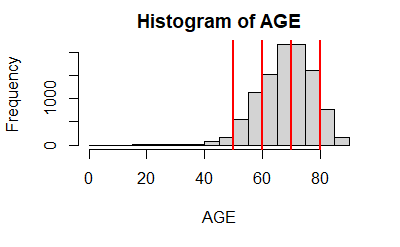

```r
hist(NCDB_lung$AGE, main="Histogram of AGE", xlab='AGE')
abline(v=c(50, 60, 70, 80), col='red', lwd=2)
```

```r
sum(is.na(NCDB_lung$AGE))
```

```
[1] 0
```

```r
sum(NCDB_lung$AGE==999)
```

```
[1] 0
```

```r
NCDB_lung$AGE_cat=ifelse(NCDB_lung$AGE<50, 1,
                         ifelse(NCDB_lung$AGE<=60, 2,
                                ifelse(NCDB_lung$AGE<=70, 3,
                                       ifelse(NCDB_lung$AGE<=80, 4, 5))))
NCDB_lung$AGE_cat=factor(NCDB_lung$AGE_cat, levels = c(1:5),
                         labels = c('Below 50', '50-60', '60-70', '70-80', 'Above 80'))
table(NCDB_lung$AGE_cat)
```

```
Below 50    50-60    60-70    70-80 Above 80
     230     1716     3676     3784      920
```

### 3.3.2 Tumor Size

```r
quantile(NCDB_lung$TUMOR_SIZE_NUM)
```

```
  0%  25%  50%  75% 100%
   2   28   35   40   50
```

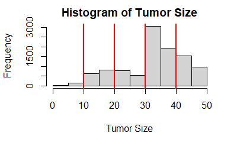

```r
hist(NCDB_lung$TUMOR_SIZE_NUM, main='Histogram of Tumor Size', xlab='Tumor Size')
abline(v=c(10, 20, 30, 40), col='red', lwd=2)
```

```r
sum(NCDB_lung$TUMOR_SIZE_NUM==999)
```

```
[1] 0
```

```r
sum(NCDB_lung$TUMOR_SIZE_NUM>50)
```

```
[1] 0
```

```r
sum(is.na(NCDB_lung$TUMOR_SIZE_NUM))
```

```
[1] 0
```

```r
NCDB_lung$TUMOR_SIZE_cat=ifelse(NCDB_lung$TUMOR_SIZE_NUM<=10, 1,
                                 ifelse(NCDB_lung$TUMOR_SIZE_NUM<=20, 2,
                                        ifelse(NCDB_lung$TUMOR_SIZE_NUM<=30, 3,
                                               ifelse(NCDB_lung$TUMOR_SIZE_NUM<=40, 4, 5))))
NCDB_lung$TUMOR_SIZE_cat=factor(NCDB_lung$TUMOR_SIZE_cat, levels = c(1, 2, 3, 4, 5),
                                 labels = c('<=1cm', '1cm-2cm', '2cm-3cm', '3cm-4cm', '4cm-5cm'))
table(NCDB_lung$TUMOR_SIZE_cat)
```

```
  <=1cm 1cm-2cm 2cm-3cm 3cm-4cm 4cm-5cm
    144    1402    1299    4988    2493
```

### 3.3.3 Urban/Rural

```r
table(NCDB_lung$UR_CD_03)
```

```
   1    2    3    4    5    6    7    8    9
5010 2054 1099  600  188  600  289  107  108
```

```r
NCDB_lung$UR_CD_03_2=ifelse(NCDB_lung$UR_CD_03 %in% c(1, 2, 3), 'Metro',
                            ifelse(NCDB_lung$UR_CD_03 %in% c(4, 5, 6, 7), 'Urban',
                                   ifelse(NCDB_lung$UR_CD_03 %in% c(8, 9), 'Rural', 'Unknown')))
table(NCDB_lung$UR_CD_03_2)
```

```
  Metro   Rural Unknown   Urban
   8163     215     271    1677
```

```r
NCDB_lung$UR_CD_13_2=ifelse(NCDB_lung$UR_CD_13 %in% c(1, 2, 3), 'Metro',
                            ifelse(NCDB_lung$UR_CD_13 %in% c(4, 5, 6, 7), 'Urban',
                                   ifelse(NCDB_lung$UR_CD_13 %in% c(8, 9), 'Rural', 'Unknown')))
table(NCDB_lung$UR_CD_13_2)
```

```
  Metro   Rural Unknown   Urban
   8400     195     271    1460
```

### 3.3.4 Race

```r
table(NCDB_lung$RACE)
```

```
   1    2    3    4    5    6    7    8   10   11   14   15   16   17   28   96   97
8898  908   33   81   15   48    9   27   40    1    2   23   10    2    1   90    4
  98   99
  71   63
```

```r
NCDB_lung$RACE2=ifelse(NCDB_lung$RACE==1, 'White',
                       ifelse(NCDB_lung$RACE==2, 'Black',
                              ifelse(NCDB_lung$RACE==99, 'Unknown',
                                     'Other')))
table(NCDB_lung$RACE2)
```

```
  Black   Other Unknown   White
    908     457      63    8898
```

```r
table(NCDB_lung$SPANISH_HISPANIC_ORIGIN)
```

```
   0    1    2    3    4    5    6    7    8    9
9828   37   22   10   23    7  216    6    6  171
```

```r
NCDB_lung$'SPANISH_ORIGIN2'=ifelse(NCDB_lung$SPANISH_HISPANIC_ORIGIN==0, 'Non-Hispanic',
                                   ifelse(NCDB_lung$SPANISH_HISPANIC_ORIGIN==9, 'Unkown', 'Hispanic'))
table(NCDB_lung$'SPANISH_ORIGIN2')
```

```
    Hispanic Non-Hispanic       Unkown
         327         9828          171
```

### 3.3.5 Squamous vs. Adenocarcinoma

```r
table(NCDB_lung$HISTOLOGY)
```

```
8000 8004 8010 8012 8013 8014 8020 8021 8022 8030 8031 8032 8033 8046 8050 8052 8070
   2    1   11   55  138    1    1    1   50    3    4    9   33   95    7    4 2163
8071 8072 8073 8074 8075 8082 8083 8084 8123 8140 8144 8200 8230 8246 8249 8250 8251
 327  187    5   15    1    6   81    9    1 3934    2    1  129   49   49   46    1
8252 8253 8254 8255 8260 8310 8323 8333 8430 8470 8480 8481 8490 8507 8550 8551 8560
   1   11   10  894  229   13   34    4   14    1  434   10    7    2  939    5  266
8562 8574 8576 8940 8980
   2   13    1    1   14
```

**There is no fifth digit in histology**

```r
NCDB_lung$Pathology=ifelse(NCDB_lung$HISTOLOGY %in% c(8070:8079), 'Squamous',
                           ifelse(NCDB_lung$HISTOLOGY %in% c(8140:8149, 8250:8259,8260-8269 ,8480:8489, 8570:8579, 8310, 8333), 'Adenocarcinoma', 'Other'))

NCDB_lung$Pathology=factor(NCDB_lung$Pathology, levels = c('Squamous', 'Adenocarcinoma','Other'))
table(NCDB_lung$Pathology)
```

```
      Squamous Adenocarcinoma          Other
          2698           5374           2254
```

### 3.3.6 Neuroendocrine

```r
NCDB_lung$Neuroendocrine =ifelse(NCDB_lung$HISTOLOGY %in% c(8242, 8245, 8246, 8249, 8013), 'Neuroendocrine', 'Other')
table(NCDB_lung$Neuroendocrine)
```

```
Neuroendocrine          Other
           236          10090
```

```r
NCDB_lung$Neuroendocrine=factor(NCDB_lung$Neuroendocrine, levels = c("Other", "Neuroendocrine"))
table(NCDB_lung$Neuroendocrine)
```

```
         Other Neuroendocrine
         10090            236
```

### 3.3.7 Visceral pleural invasion

```r
NCDB_lung$Visceral_Pleural_Invasion=ifelse(NCDB_lung$CS_SITESPECIFIC_FACTOR_2 %in% c(10, 20), 'Present',
                                           'Other')
```

```r
table(NCDB_lung$TUMOR_SIZE_cat, NCDB_lung$Visceral_Pleural_Invasion)
```

```
          Other Present
  <=1cm       0     144
  1cm-2cm     0    1402
  2cm-3cm     0    1299
  3cm-4cm  4277     711
  4cm-5cm  2099     394
```

### 3.3.8 Positive Margins

```r
table(NCDB_lung$RX_SUMM_SURGICAL_MARGINS )
```

```
    0     1     2     3     7     9
10093    73   109     7     8    36
```

```r
NCDB_lung$Margins=ifelse(NCDB_lung$RX_SUMM_SURGICAL_MARGINS %in% c(1, 2, 3), 'Positive',
                         ifelse(NCDB_lung$RX_SUMM_SURGICAL_MARGINS==0, 'Zero', 'Other'))
NCDB_lung$Margins=factor(NCDB_lung$Margins, levels = c('Zero', 'Positive', 'Other'))
table(NCDB_lung$Margins)
```

```
    Zero Positive    Other
   10093      189       44
```

### 3.3.9 <10 lymph nodes sampled

```r
table(NCDB_lung$REGIONAL_NODES_EXAMINED)
```

```
  1   2   3   4   5   6   7   8   9  10  11  12  13  14  15  16  17  18  19  20  21
283 344 474 509 595 599 592 525 577 589 507 492 456 412 365 331 282 246 258 209 167
 22  23  24  25  26  27  28  29  30  31  32  33  34  35  36  37  38  39  40  41  42
143 131 111  95  67  77  62  61  45  39  42  31  22  26  19  13  16  15  20  11   9
 43  44  45  46  47  48  49  50  51  52  53  54  55  56  57  58  59  60  61  62  63
  5   4   4   5   6   3   3   6   3   1   2   7   3   1   2   2   1   2   1   1   1
 64  65  66  67  75  80  82  87  90  95  96  97  98
  1   2   1   2   1   1   2   2   2  26  32 229  95
```

```r
NCDB_lung$Lymph_Nodes_Sampled =ifelse(NCDB_lung$REGIONAL_NODES_EXAMINED<10, '<10', ifelse(NCDB_lung$REGIONAL_NODES_EXAMINED %in% c(95, 96, 97, 98 ), 'Unknown', '>=10'))

table(NCDB_lung$Lymph_Nodes_Sampled)
```

```
    <10    >=10 Unknown
   4498    5446     382
```

### 3.3.10 Excision or resection of less than one lobe

```r
NCDB_lung$Excision_less_than1=ifelse(NCDB_lung$RX_SUMM_SURG_PRIM_SITE %in% c(20:25), TRUE, FALSE)
NCDB_lung$Excision_less_than1=factor(NCDB_lung$Excision_less_than1, levels = c(TRUE, FALSE))
table(NCDB_lung$Excision_less_than1)
```

```
 TRUE FALSE
 1322  9004
```

### 3.3.11 Local tumor destruction

NO local turmor destruction!

```r
table(NCDB_lung$RX_SUMM_SURG_PRIM_SITE)
```

```
  20   21   22   23   25   30   33   45   46   47   55   56   65   66   80   90
  26  900  389    2    5  786 7860  167   55    3   28   94    1    1    3    6
```

```r
NCDB_lung$Local_Tumor_Destruction=ifelse(NCDB_lung$RX_SUMM_SURG_PRIM_SITE %in% c(12, 13, 15), TRUE, FALSE)
table(NCDB_lung$Local_Tumor_Destruction)
```

```
FALSE
10326
```

## 3.4 label levels in those factors

```r
NCDB_lung$INSURANCE_STATUS=factor(NCDB_lung$INSURANCE_STATUS, levels=c(0, 1, 2, 3, 4, 9), labels = c("Not Insured", "Private", "Medicaid", "Medicare","Other Government", "Unknown"))
NCDB_lung$SEX=factor(NCDB_lung$SEX, levels = c(1, 2), labels = c("Male", "Female"))
NCDB_lung$RACE2=factor(NCDB_lung$RACE2, levels = c("White", "Black", "Other", "Unknown"))
NCDB_lung$MED_INC_QUAR_00=factor(NCDB_lung$MED_INC_QUAR_00, levels = c(1, 2, 3, 4), labels = c("< $30,000", "$30,000 - $34,999", "$35,000 - $45,999", ">=$46,000"))
NCDB_lung$MED_INC_QUAR_12=factor(NCDB_lung$MED_INC_QUAR_12, levels = c(1, 2, 3, 4), labels = c("< $38,000", "$38,000 - $47,999", "$48,000 - $62,999", ">=$63,000"))
NCDB_lung$NO_HSD_QUAR_00=factor(NCDB_lung$NO_HSD_QUAR_00, levels = c(1, 2, 3, 4), labels = c(">=29.0%", "20.0% - 28.9%", "14.0%-19.9%", "< 14.0%"))
NCDB_lung$NO_HSD_QUAR_12=factor(NCDB_lung$NO_HSD_QUAR_12, levels = c(1, 2, 3, 4), labels = c(">=21.0%", "13.0% - 20.9%", "7.0%-12.9%", "< 7.0%"))
NCDB_lung$UR_CD_03_2=factor(NCDB_lung$UR_CD_03_2, levels = c("Metro", "Urban", "Rural"))
NCDB_lung$UR_CD_13_2=factor(NCDB_lung$UR_CD_13_2, levels = c("Metro", "Urban", "Rural"))

NCDB_lung$GRADE=factor(NCDB_lung$GRADE, levels = c(1, 2, 3, 4, 9), labels = c("Well differentiated", "Moderately differentiated", "Poorly differentiated", "Undifferentiated", "Unknown"))

NCDB_lung$LYMPH_VASCULAR_INVASION=factor(NCDB_lung$LYMPH_VASCULAR_INVASION, levels = c(0, 1, 8, 9), labels = c("Absent", "Present", "Not applicable", "Unknown"))



#NCDB_lung$RX_SUMM_SURGICAL_MARGINS=factor(NCDB_lung$RX_SUMM_SURGICAL_MARGINS, levels = c(0, 1, 2, 3, 7, 9), labels = c("No residual tumor", "Residual tumor", "Microscopic residual tumor", "Macroscopic residual tumor", "Margins not evaluable", "Unknown"))
```

**Remove empty category of LYMPH_VASCULAR_INVASION**

```r
NCDB_lung$LYMPH_VASCULAR_INVASION2=factor(NCDB_lung$LYMPH_VASCULAR_INVASION, levels = c("Absent", "Present",  "Unknown"), labels = c("Absent", "Present",  "Unknown"))
table(NCDB_lung$LYMPH_VASCULAR_INVASION2)
```

```
 Absent Present Unknown
   8015    1719     592
```

# 4 Table 1

Comparing demographics, clinicopath, molecular features for patients with and without chemotherapy

## 4.1 Table 1

```r
# the order in this vector influences the order of variables showing up in the table
include_columns = c(
  "YEAR_OF_DIAGNOSIS",
  "AGE_cat",
  "SEX" ,
  "RACE2",
  "SPANISH_ORIGIN2",
  "INSURANCE_STATUS" ,
  "MED_INC_QUAR_00",
  "NO_HSD_QUAR_00",
  "UR_CD_03_2",
  "MED_INC_QUAR_12",
  "NO_HSD_QUAR_12",
  "UR_CD_13_2",
  "CROWFLY",
  "CDCC_TOTAL_BEST",
  "TUMOR_SIZE_cat",
  "GRADE",
  "Pathology",
  "Neuroendocrine",
  "Visceral_Pleural_Invasion",
  "LYMPH_VASCULAR_INVASION2" ,
  "Margins",
  "Lymph_Nodes_Sampled",
  "Excision_less_than1",
  "Chemo"
)


relabel_columns=list(YEAR_OF_DIAGNOSIS ~'Year',
                      AGE_cat ~ 'Age',
                     SEX ~ 'Gender',
                     RACE2 ~ 'Race',
                     SPANISH_ORIGIN2~ 'Spanish Origin',
                     INSURANCE_STATUS~ 'Insurance Status',
                     MED_INC_QUAR_00 ~ 'Median Income Quartiles',
                     NO_HSD_QUAR_00 ~ 'No High School Degree',
                     MED_INC_QUAR_12 ~ 'Median Income Quartiles 2012',
                     NO_HSD_QUAR_12 ~ 'No High School Degree 2012',
                     UR_CD_03_2 ~ 'Urban/Rural',
                     UR_CD_13_2 ~ 'Urban/Rural 2013',
                     CROWFLY ~ 'Great Circle Distance',
                     CDCC_TOTAL_BEST ~ 'Charlson-Deyo Score',
                     TUMOR_SIZE_cat ~ 'Tumor Size',
                     LYMPH_VASCULAR_INVASION2 ~ 'Vascular Invasion',
                     Lymph_Nodes_Sampled ~ 'Lymph nodes sampled ',
                     Excision_less_than1='Excision/Resection of <1 lobe ',
                     Visceral_Pleural_Invasion~'Visceral Pleural Invasion')
```

# 5 Data check table 1

```r
library(finalfit)
library(summarytools)
#check summary stats and distributions
NCDB_lung[,include_columns] %>% dfSummary()
```

```
Data Frame Summary
Dimensions: 10326 x 24
Duplicates: 53

---------------------------------------------------------------------------------------------------------------------------------
No   Variable                    Stats / Values                 Freqs (% of Valid)     Graph                 Valid      Missing
---- --------------------------- ------------------------------ ---------------------- --------------------- ---------- ---------
1    YEAR_OF_DIAGNOSIS           Mean (sd) : 2016.4 (0.8)       2010 :   26 ( 0.3%)                          10326      0
     [integer]                   min < med < max:               2011 :   16 ( 0.2%)                          (100.0%)   (0.0%)
                                 2010 < 2016 < 2017             2012 :   28 ( 0.3%)
                                 IQR (CV) : 1 (0)               2013 :   34 ( 0.3%)
                                                                2014 :   55 ( 0.5%)
                                                                2015 :  261 ( 2.5%)
                                                                2016 : 4767 (46.2%)    IIIIIIIII
                                                                2017 : 5139 (49.8%)    IIIIIIIII

2    AGE_cat                     1. Below 50                     230 ( 2.2%)                                 10326      0
     [factor]                    2. 50-60                       1716 (16.6%)           III                   (100.0%)   (0.0%)
                                 3. 60-70                       3676 (35.6%)           IIIIIII
                                 4. 70-80                       3784 (36.6%)           IIIIIII
                                 5. Above 80                     920 ( 8.9%)           I

3    SEX                         1. Male                        4761 (46.1%)           IIIIIIIII             10326      0
     [factor]                    2. Female                      5565 (53.9%)           IIIIIIIIII            (100.0%)   (0.0%)

4    RACE2                       1. White                       8898 (86.2%)           IIIIIIIIIIIIIIIII     10326      0
     [factor]                    2. Black                        908 ( 8.8%)           I                     (100.0%)   (0.0%)
                                 3. Other                        457 ( 4.4%)
                                 4. Unknown                       63 ( 0.6%)

5    SPANISH_ORIGIN2             1. Hispanic                     327 ( 3.2%)                                 10326      0
     [character]                 2. Non-Hispanic                9828 (95.2%)           IIIIIIIIIIIIIIIIIII   (100.0%)   (0.0%)
                                 3. Unkown                       171 ( 1.7%)

6    INSURANCE_STATUS            1. Not Insured                  119 ( 1.2%)                                 10326      0
     [factor]                    2. Private                     2596 (25.1%)           IIIII                 (100.0%)   (0.0%)
                                 3. Medicaid                     595 ( 5.8%)           I
                                 4. Medicare                    6776 (65.6%)           IIIIIIIIIIIII
                                 5. Other Government             139 ( 1.3%)
                                 6. Unknown                      101 ( 1.0%)
```

[output cut: 65 more lines]

```

21   Margins                     1. Zero                        10093 (97.7%)          IIIIIIIIIIIIIIIIIII   10326      0
     [factor]                    2. Positive                      189 ( 1.8%)                                (100.0%)   (0.0%)
                                 3. Other                          44 ( 0.4%)

22   Lymph_Nodes_Sampled         1. <10                         4498 (43.6%)           IIIIIIII              10326      0
     [character]                 2. >=10                        5446 (52.7%)           IIIIIIIIII            (100.0%)   (0.0%)
                                 3. Unknown                      382 ( 3.7%)

23   Excision_less_than1         1. TRUE                        1322 (12.8%)           II                    10326      0
     [factor]                    2. FALSE                       9004 (87.2%)           IIIIIIIIIIIIIIIII     (100.0%)   (0.0%)

24   Chemo                       1. Chemo                       1719 (16.6%)           III                   10326      0
     [factor]                    2. No Chemo                    8607 (83.4%)           IIIIIIIIIIIIIIII      (100.0%)   (0.0%)
---------------------------------------------------------------------------------------------------------------------------------
```

```r
NCDB_lung[,include_columns] %>% missing_plot()
```

[output not shown]

# 6 Create Tables

```r
#define new fisher sim test
fisher.test.simulate.p.values <- function(data, variable, by, ...) {
  result <- list()
  test_results <- stats::fisher.test(data[[variable]], data[[by]], simulate.p.value = TRUE)
  result$p <- test_results$p.value
  result$test <- test_results$method
  return(result)
}

table1 <-NCDB_lung%>% tbl_summary( by=Chemo, missing='no',
                                        statistic = list(all_continuous() ~ "{mean} ({sd})"),
                                        label = relabel_columns, include=all_of(include_columns))%>%
  add_p(test = list(all_categorical() ~ "fisher.test.simulate.p.values") )%>%
  bold_labels()

table1  %>%
  as_flex_table()%>%flextable::save_as_docx(., path = "table1.docx")
table1
```

| **Characteristic** | **Chemo**, N = 1,719<sup>1</sup> | **No Chemo**, N = 8,607<sup>1</sup> | **p-value**<sup>2</sup> |
| --- | --- | --- | --- |
| Year |  |  | 0.8 |
| 2010 | 3 (0.2%) | 23 (0.3%) |  |
| 2011 | 2 (0.1%) | 14 (0.2%) |  |
| 2012 | 5 (0.3%) | 23 (0.3%) |  |
| 2013 | 5 (0.3%) | 29 (0.3%) |  |
| 2014 | 6 (0.3%) | 49 (0.6%) |  |
| 2015 | 43 (2.5%) | 218 (2.5%) |  |
| 2016 | 772 (45%) | 3,995 (46%) |  |
| 2017 | 883 (51%) | 4,256 (49%) |  |
| Age |  |  | <0.001 |
| Below 50 | 63 (3.7%) | 167 (1.9%) |  |
| 50-60 | 446 (26%) | 1,270 (15%) |  |
| 60-70 | 719 (42%) | 2,957 (34%) |  |
| 70-80 | 467 (27%) | 3,317 (39%) |  |
| Above 80 | 24 (1.4%) | 896 (10%) |  |
| Gender |  |  | 0.12 |
| Male | 763 (44%) | 3,998 (46%) |  |
| Female | 956 (56%) | 4,609 (54%) |  |
| Race |  |  | 0.5 |
| White | 1,466 (85%) | 7,432 (86%) |  |
| Black | 166 (9.7%) | 742 (8.6%) |  |
| Other | 78 (4.5%) | 379 (4.4%) |  |
| Unknown | 9 (0.5%) | 54 (0.6%) |  |
| Spanish Origin |  |  | 0.8 |
| Hispanic | 55 (3.2%) | 272 (3.2%) |  |
| Non-Hispanic | 1,633 (95%) | 8,195 (95%) |  |
| Unkown | 31 (1.8%) | 140 (1.6%) |  |
| Insurance Status |  |  | <0.001 |
| Not Insured | 24 (1.4%) | 95 (1.1%) |  |
| Private | 580 (34%) | 2,016 (23%) |  |

[output cut: 75 more lines]

<sup>1</sup> n (%); Mean (SD)  
<sup>2</sup> Fisher's Exact Test for Count Data with simulated p-value (based on 2000 replicates); Fisher's Exact Test for Count Data; Wilcoxon rank sum test

# 7 Predictors for receipt of adjuvant chemotherapy

From Table 1, we can see variables correlated to Chemotherapy receipt are

- Age
- Insurance Status
- Charlson-Deyo Score
- Tumor Size
- Grade
- Neuroendocrine
- Visceral Pleural Invasion
- Vascular Invasion
- Margins
- Lymph nodes sampled
- Excision_less_than1

Pathology is not significant in Table 1, but let’s include it by so far.

We do logistic regression with receipt of chemotherapy as response and the variables above as predictors.

```r
NCDB_lung$Chemo2=ifelse(NCDB_lung$Chemo=='Chemo', 1, 0); # since Chemo is already factorized

table(NCDB_lung$Chemo, NCDB_lung$Chemo2)
```

```
              0    1
  Chemo       0 1719
  No Chemo 8607    0
```

```r
NCDB_lung$CDCC_TOTAL_BEST=as.factor(NCDB_lung$CDCC_TOTAL_BEST)
fit1=glm(Chemo2~AGE_cat+
  INSURANCE_STATUS+
  CDCC_TOTAL_BEST+
  TUMOR_SIZE_cat+
  GRADE+
  Pathology+
  Neuroendocrine+
  Visceral_Pleural_Invasion+
  LYMPH_VASCULAR_INVASION2+
  Margins+
  Lymph_Nodes_Sampled+
  Excision_less_than1, data=NCDB_lung, family = binomial)
summary(fit1)
```

```
Call:
glm(formula = Chemo2 ~ AGE_cat + INSURANCE_STATUS + CDCC_TOTAL_BEST +
    TUMOR_SIZE_cat + GRADE + Pathology + Neuroendocrine + Visceral_Pleural_Invasion +
    LYMPH_VASCULAR_INVASION2 + Margins + Lymph_Nodes_Sampled +
    Excision_less_than1, family = binomial, data = NCDB_lung)

Deviance Residuals:
    Min       1Q   Median       3Q      Max
-1.5259  -0.6236  -0.4771  -0.3170   2.9877

Coefficients:
                                 Estimate Std. Error z value Pr(>|z|)
(Intercept)                      -2.31621    0.39511  -5.862 4.57e-09 ***
AGE_cat50-60                     -0.01072    0.16593  -0.065 0.948470
AGE_cat60-70                     -0.32983    0.16549  -1.993 0.046255 *
AGE_cat70-80                     -0.86353    0.17187  -5.024 5.05e-07 ***
AGE_catAbove 80                  -2.59869    0.26572  -9.780  < 2e-16 ***
INSURANCE_STATUSPrivate           0.28470    0.24727   1.151 0.249572
INSURANCE_STATUSMedicaid          0.20400    0.26259   0.777 0.437241
INSURANCE_STATUSMedicare          0.13944    0.24898   0.560 0.575456
INSURANCE_STATUSOther Government -0.36904    0.36324  -1.016 0.309640
INSURANCE_STATUSUnknown          -0.17621    0.38758  -0.455 0.649377
CDCC_TOTAL_BEST1                 -0.03078    0.06591  -0.467 0.640492
CDCC_TOTAL_BEST2                 -0.03340    0.09281  -0.360 0.718963
CDCC_TOTAL_BEST3                 -0.43252    0.12114  -3.570 0.000357 ***
TUMOR_SIZE_cat1cm-2cm            -0.36521    0.25187  -1.450 0.147052
TUMOR_SIZE_cat2cm-3cm            -0.18241    0.25227  -0.723 0.469634
TUMOR_SIZE_cat3cm-4cm             0.17868    0.25179   0.710 0.477915
TUMOR_SIZE_cat4cm-5cm             1.30463    0.25320   5.153 2.57e-07 ***
GRADEModerately differentiated    0.20920    0.10160   2.059 0.039489 *
GRADEPoorly differentiated        0.44597    0.10397   4.289 1.79e-05 ***
GRADEUndifferentiated             0.83765    0.23384   3.582 0.000341 ***
GRADEUnknown                      0.18013    0.13040   1.381 0.167172
PathologyAdenocarcinoma           0.19917    0.07060   2.821 0.004785 **
PathologyOther                    0.14265    0.08616   1.656 0.097781 .
NeuroendocrineNeuroendocrine      0.50890    0.16901   3.011 0.002604 **
Visceral_Pleural_InvasionPresent  0.40420    0.08317   4.860 1.17e-06 ***
LYMPH_VASCULAR_INVASION2Present   0.36570    0.07114   5.140 2.74e-07 ***
LYMPH_VASCULAR_INVASION2Unknown   0.07833    0.12005   0.652 0.514079
MarginsPositive                   0.53677    0.18258   2.940 0.003284 **
MarginsOther                      0.72016    0.36604   1.967 0.049132 *
Lymph_Nodes_Sampled>=10           0.08367    0.05882   1.422 0.154891
Lymph_Nodes_SampledUnknown        0.01043    0.15640   0.067 0.946850
Excision_less_than1FALSE         -0.02306    0.09496  -0.243 0.808168
---
Signif. codes:  0 ‘***’ 0.001 ‘**’ 0.01 ‘*’ 0.05 ‘.’ 0.1 ‘ ’ 1

(Dispersion parameter for binomial family taken to be 1)

    Null deviance: 9298.5  on 10325  degrees of freedom
Residual deviance: 8355.1  on 10294  degrees of freedom
AIC: 8419.1

Number of Fisher Scoring iterations: 6
```

## 7.1 Backward variable selection

```r
backward=step(fit1, direction = "backward")
```

```
Start:  AIC=8419.08
Chemo2 ~ AGE_cat + INSURANCE_STATUS + CDCC_TOTAL_BEST + TUMOR_SIZE_cat +
    GRADE + Pathology + Neuroendocrine + Visceral_Pleural_Invasion +
    LYMPH_VASCULAR_INVASION2 + Margins + Lymph_Nodes_Sampled +
    Excision_less_than1

                            Df Deviance    AIC
- Excision_less_than1        1   8355.1 8417.1
- Lymph_Nodes_Sampled        2   8357.2 8417.2
<none>                           8355.1 8419.1
- INSURANCE_STATUS           5   8366.5 8420.5
- Pathology                  2   8363.1 8423.1
- Neuroendocrine             1   8363.8 8425.8
- Margins                    2   8366.6 8426.6
- CDCC_TOTAL_BEST            3   8368.9 8426.9
- Visceral_Pleural_Invasion  1   8377.9 8439.9
- LYMPH_VASCULAR_INVASION2   2   8380.7 8440.7
- GRADE                      4   8386.9 8442.9
- AGE_cat                    4   8634.7 8690.7
- TUMOR_SIZE_cat             4   8756.7 8812.7

Step:  AIC=8417.14
Chemo2 ~ AGE_cat + INSURANCE_STATUS + CDCC_TOTAL_BEST + TUMOR_SIZE_cat +
    GRADE + Pathology + Neuroendocrine + Visceral_Pleural_Invasion +
    LYMPH_VASCULAR_INVASION2 + Margins + Lymph_Nodes_Sampled

                            Df Deviance    AIC
- Lymph_Nodes_Sampled        2   8357.2 8415.2
<none>                           8355.1 8417.1
- INSURANCE_STATUS           5   8366.6 8418.6
- Pathology                  2   8363.2 8421.2
- Neuroendocrine             1   8363.9 8423.9
- Margins                    2   8366.7 8424.7
- CDCC_TOTAL_BEST            3   8368.9 8424.9
- Visceral_Pleural_Invasion  1   8378.0 8438.0
- LYMPH_VASCULAR_INVASION2   2   8380.8 8438.8
- GRADE                      4   8387.0 8441.0
- AGE_cat                    4   8635.0 8689.0
- TUMOR_SIZE_cat             4   8759.5 8813.5

Step:  AIC=8415.16
Chemo2 ~ AGE_cat + INSURANCE_STATUS + CDCC_TOTAL_BEST + TUMOR_SIZE_cat +
    GRADE + Pathology + Neuroendocrine + Visceral_Pleural_Invasion +
    LYMPH_VASCULAR_INVASION2 + Margins

                            Df Deviance    AIC
<none>                           8357.2 8415.2
- INSURANCE_STATUS           5   8368.7 8416.7
- Pathology                  2   8365.1 8419.1
- Neuroendocrine             1   8365.8 8421.8
- Margins                    2   8368.3 8422.3
- CDCC_TOTAL_BEST            3   8371.1 8423.1
- Visceral_Pleural_Invasion  1   8380.1 8436.1
- LYMPH_VASCULAR_INVASION2   2   8383.3 8437.3
- GRADE                      4   8389.1 8439.1
- AGE_cat                    4   8638.3 8688.3
- TUMOR_SIZE_cat             4   8765.2 8815.2
```

## 7.2 Forward variable selection

```r
fit0=glm(Chemo~ 1, data = NCDB_lung, family = binomial(link="logit"))
forward=step(fit0, scope=list(lower=formula(fit0),upper=formula(fit1)), direction="forward")
```

```
Start:  AIC=9300.55
Chemo ~ 1

                            Df Deviance    AIC
+ TUMOR_SIZE_cat             4   8910.1 8920.1
+ AGE_cat                    4   8920.4 8930.4
+ INSURANCE_STATUS           5   9187.6 9199.6
+ GRADE                      4   9226.1 9236.1
+ LYMPH_VASCULAR_INVASION2   2   9255.6 9261.6
+ Neuroendocrine             1   9276.4 9280.4
+ CDCC_TOTAL_BEST            3   9276.3 9284.3
+ Excision_less_than1        1   9285.2 9289.2
+ Margins                    2   9284.4 9290.4
+ Lymph_Nodes_Sampled        2   9289.6 9295.6
+ Visceral_Pleural_Invasion  1   9291.8 9295.8
+ Pathology                  2   9293.3 9299.3
<none>                           9298.5 9300.5

Step:  AIC=8920.14
Chemo ~ TUMOR_SIZE_cat

                            Df Deviance    AIC
+ AGE_cat                    4   8511.6 8529.6
+ INSURANCE_STATUS           5   8792.7 8812.7
+ GRADE                      4   8856.5 8874.5
+ LYMPH_VASCULAR_INVASION2   2   8867.6 8881.6
+ Visceral_Pleural_Invasion  1   8884.4 8896.4
+ CDCC_TOTAL_BEST            3   8887.4 8903.4
+ Neuroendocrine             1   8892.6 8904.6
+ Pathology                  2   8892.8 8906.8
+ Margins                    2   8900.4 8914.4
<none>                           8910.1 8920.1
+ Lymph_Nodes_Sampled        2   8906.6 8920.6
+ Excision_less_than1        1   8909.1 8921.1

Step:  AIC=8529.59
Chemo ~ TUMOR_SIZE_cat + AGE_cat

                            Df Deviance    AIC
+ LYMPH_VASCULAR_INVASION2   2   8468.8 8490.8
```

[output cut: 97 more lines]

```
                      Df Deviance    AIC
+ INSURANCE_STATUS     5   8357.2 8415.2
<none>                     8368.7 8416.7
+ Lymph_Nodes_Sampled  2   8366.6 8418.6
+ Excision_less_than1  1   8368.7 8418.7

Step:  AIC=8415.16
Chemo ~ TUMOR_SIZE_cat + AGE_cat + LYMPH_VASCULAR_INVASION2 +
    Visceral_Pleural_Invasion + GRADE + CDCC_TOTAL_BEST + Neuroendocrine +
    Margins + Pathology + INSURANCE_STATUS

                      Df Deviance    AIC
<none>                     8357.2 8415.2
+ Lymph_Nodes_Sampled  2   8355.1 8417.1
+ Excision_less_than1  1   8357.2 8417.2
```

```r
backward$formula
```

```
Chemo2 ~ AGE_cat + INSURANCE_STATUS + CDCC_TOTAL_BEST + TUMOR_SIZE_cat +
    GRADE + Pathology + Neuroendocrine + Visceral_Pleural_Invasion +
    LYMPH_VASCULAR_INVASION2 + Margins
```

```r
forward$formula
```

```
Chemo ~ TUMOR_SIZE_cat + AGE_cat + LYMPH_VASCULAR_INVASION2 +
    Visceral_Pleural_Invasion + GRADE + CDCC_TOTAL_BEST + Neuroendocrine +
    Margins + Pathology + INSURANCE_STATUS
```

**We can see we get the same results in backward and forward variable selection**

```r
fit1_final=backward
```

## 7.3 Interpret Result

```r
summary(fit1_final)
```

```
Call:
glm(formula = Chemo2 ~ AGE_cat + INSURANCE_STATUS + CDCC_TOTAL_BEST +
    TUMOR_SIZE_cat + GRADE + Pathology + Neuroendocrine + Visceral_Pleural_Invasion +
    LYMPH_VASCULAR_INVASION2 + Margins, family = binomial, data = NCDB_lung)

Deviance Residuals:
    Min       1Q   Median       3Q      Max
-1.5105  -0.6259  -0.4780  -0.3120   2.9732

Coefficients:
                                  Estimate Std. Error z value Pr(>|z|)
(Intercept)                      -2.303190   0.390488  -5.898 3.67e-09 ***
AGE_cat50-60                     -0.007565   0.165896  -0.046 0.963626
AGE_cat60-70                     -0.326502   0.165428  -1.974 0.048419 *
AGE_cat70-80                     -0.860952   0.171828  -5.011 5.43e-07 ***
AGE_catAbove 80                  -2.598251   0.265567  -9.784  < 2e-16 ***
INSURANCE_STATUSPrivate           0.281815   0.247140   1.140 0.254158
INSURANCE_STATUSMedicaid          0.197153   0.262449   0.751 0.452529
INSURANCE_STATUSMedicare          0.137630   0.248852   0.553 0.580224
INSURANCE_STATUSOther Government -0.379536   0.362990  -1.046 0.295754
INSURANCE_STATUSUnknown          -0.180649   0.387464  -0.466 0.641047
CDCC_TOTAL_BEST1                 -0.031964   0.065890  -0.485 0.627601
CDCC_TOTAL_BEST2                 -0.034743   0.092800  -0.374 0.708119
CDCC_TOTAL_BEST3                 -0.433549   0.121089  -3.580 0.000343 ***
TUMOR_SIZE_cat1cm-2cm            -0.360006   0.251442  -1.432 0.152210
TUMOR_SIZE_cat2cm-3cm            -0.173565   0.250977  -0.692 0.489215
TUMOR_SIZE_cat3cm-4cm             0.189988   0.249794   0.761 0.446908
TUMOR_SIZE_cat4cm-5cm             1.317033   0.250757   5.252 1.50e-07 ***
GRADEModerately differentiated    0.210700   0.101574   2.074 0.038046 *
GRADEPoorly differentiated        0.448502   0.103928   4.316 1.59e-05 ***
GRADEUndifferentiated             0.833102   0.233906   3.562 0.000368 ***
GRADEUnknown                      0.183057   0.130331   1.405 0.160152
PathologyAdenocarcinoma           0.197918   0.070562   2.805 0.005034 **
PathologyOther                    0.143667   0.086138   1.668 0.095341 .
NeuroendocrineNeuroendocrine      0.506360   0.168949   2.997 0.002725 **
Visceral_Pleural_InvasionPresent  0.405281   0.083141   4.875 1.09e-06 ***
LYMPH_VASCULAR_INVASION2Present   0.369250   0.071069   5.196 2.04e-07 ***
LYMPH_VASCULAR_INVASION2Unknown   0.078513   0.119963   0.654 0.512804
MarginsPositive                   0.527511   0.182200   2.895 0.003789 **
MarginsOther                      0.704733   0.365572   1.928 0.053886 .
---
Signif. codes:  0 ‘***’ 0.001 ‘**’ 0.01 ‘*’ 0.05 ‘.’ 0.1 ‘ ’ 1

(Dispersion parameter for binomial family taken to be 1)

    Null deviance: 9298.5  on 10325  degrees of freedom
Residual deviance: 8357.2  on 10297  degrees of freedom
AIC: 8415.2

Number of Fisher Scoring iterations: 6
```

## 7.4 Diagnosis

```r
library(LogisticDx)
```

### 7.4.1 Influential Obs

```r
DX=dx(fit1_final, byCov=FALSE)
```

**These are difference in beta, deviance and chi-square statistic after removing each obs**

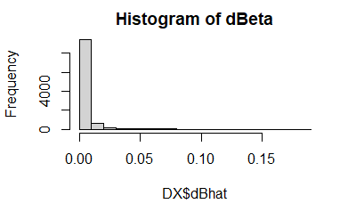

```r
hist(DX$dBhat, main='Histogram of dBeta')
```

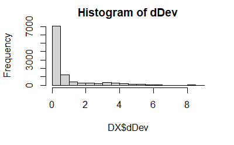

```r
hist(DX$dDev, main='Histogram of dDev')
```

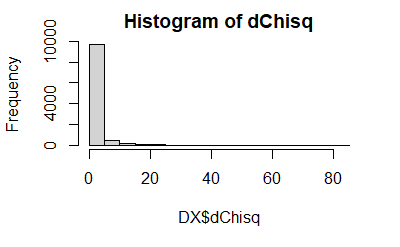

```r
hist(DX$dChisq, main='Histogram of dChisq')
```

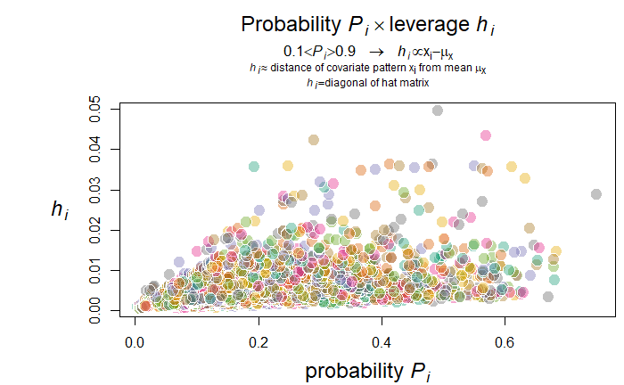

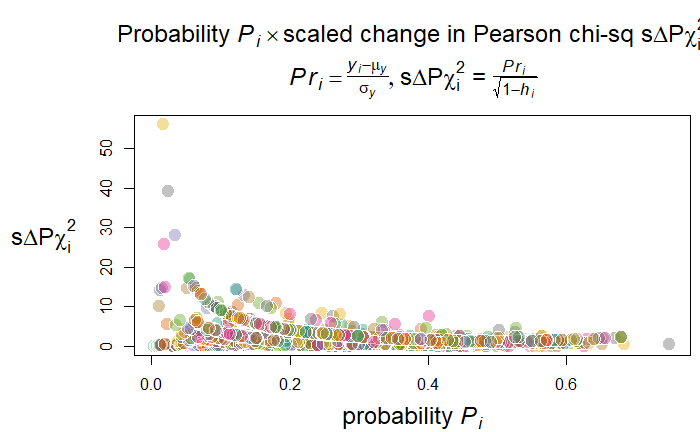

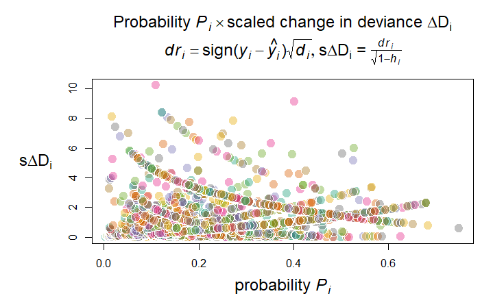

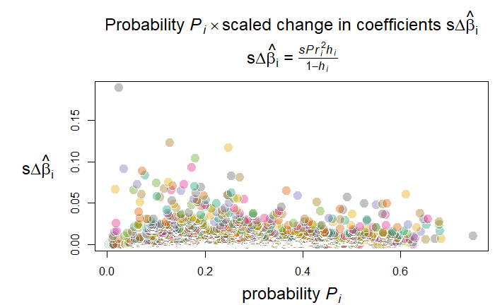

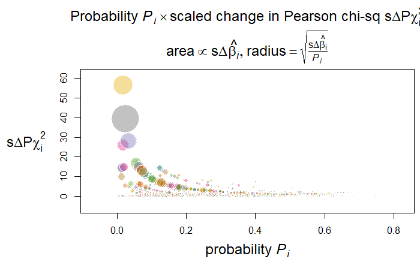

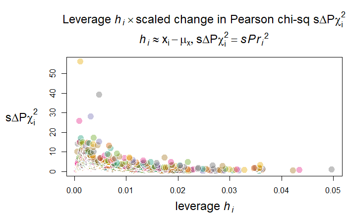

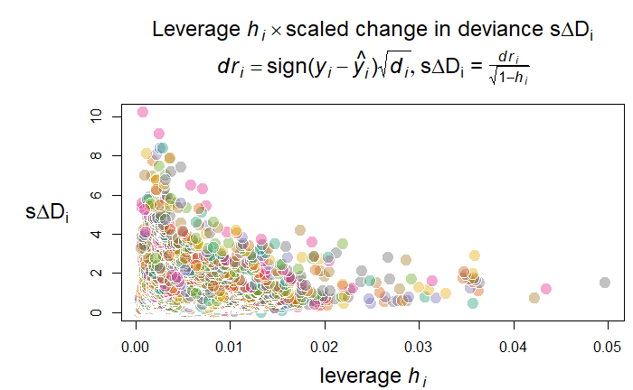

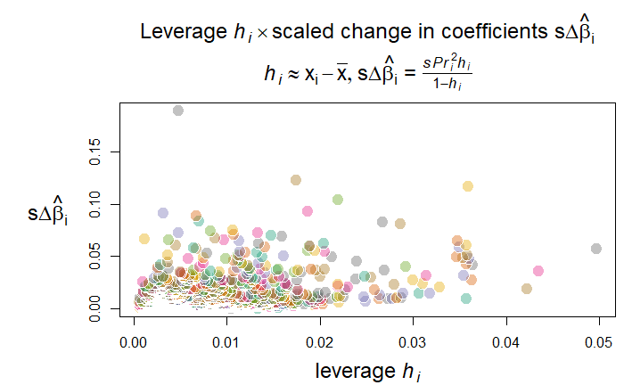

```r
plot(fit1_final, identify = TRUE, devNew = FALSE)
```

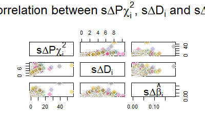

```r
NA
```

### 7.4.2 Goodness of Fit

We can see the model passed moste tests for goodness of fit.

| test | stat | val | df | pVal |
| --- | --- | --- | --- | --- |
| HL | chiSq | 1.4197707 | 7 | 0.98495800 |
| mHL | F | 0.8800479 | 8 | 0.53240057 |
| OsRo | Z | 1.0537400 | NA | 0.29200196 |
| SstPgeq0.5 | Z | 1.7364203 | NA | 0.08248954 |
| SstPl0.5 | Z | 0.7058921 | NA | 0.48025521 |
| SstBoth | chiSq | 3.5134392 | 2 | 0.17261017 |
| SllPgeq0.5 | chiSq | 2.7991379 | 1 | 0.09431501 |
| SllPl0.5 | chiSq | 0.5001472 | 1 | 0.47943544 |
| SllBoth | chiSq | 2.8121667 | 2 | 0.24510139 |

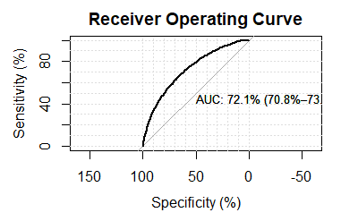

```r
LogisticDx::gof(fit1_final, g=9, plotROC=TRUE)$gof
```

### 7.4.3 Residual plot

We can deal with outliars later.

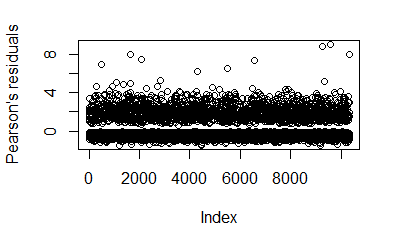

```r
plot(rstandard(fit1_final, type = "pearson"), ylab="Pearson's residuals")
```

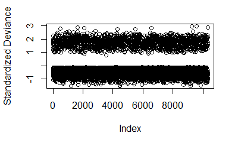

```r
plot(rstandard(fit1_final, type = "deviance"), ylab='Standardized Deviance')
```

# 8 Table 1 Adjusted

TUMOR_SIZE_cat + AGE_cat + LYMPH_VASCULAR_INVASION2 + Visceral_Pleural_Invasion + GRADE + CDCC_TOTAL_BEST + Neuroendocrine + Margins + Pathology + INSURANCE_STATUS

```r
NCDB_lung$Chemo2=ifelse(NCDB_lung$Chemo=='Chemo', 1, 0); # since Chemo is already factorized

include_columns = c(
  'AGE_cat',
  'TUMOR_SIZE_cat',
  'INSURANCE_STATUS',
  'CDCC_TOTAL_BEST',
  'GRADE',
  'Pathology',
  'Neuroendocrine',
  'Visceral_Pleural_Invasion',
  'LYMPH_VASCULAR_INVASION2',
  'Margins'
)

relabel_columns=list(AGE_cat ~ 'Age',
                     TUMOR_SIZE_cat ~ 'Tumor Size',
                     INSURANCE_STATUS~ 'Insurance Status',
                     CDCC_TOTAL_BEST ~ 'Charlson-Deyo Score',
                     GRADE~'Grade',
                     LYMPH_VASCULAR_INVASION2 ~ 'Vascular Invasion',
                     Visceral_Pleural_Invasion ~ 'Visceral Pleural Invasion')

table1_uv=NCDB_lung[,c('Chemo2', include_columns)] %>%
  tbl_uvregression(
    method = glm,
    y = Chemo2,
    exponentiate = TRUE,
    label = relabel_columns
  )%>%
  modify_header(
    update = list(
      estimate ~ "**OR**"
    )) %>%  modify_footnote(
    update = estimate ~
      "OR=Odds Ratio"
  )

table1_mv=fit1%>%tbl_regression(exponentiate = TRUE, label = relabel_columns)%>%
  modify_header(
    update = list(
      estimate ~ "**OR**"
    )) %>%  modify_footnote(
    update = estimate ~
      "OR=Odds Ratio"
  )

Table1_merge <- tbl_merge(
  list(table1_uv, table1_mv),
  tab_spanner = c("**Univariate analysis**", "**Multivariable analysis**")
  )
Table1_merge%>% as_flex_table()%>%flextable::save_as_docx(., path = "table1_merge.docx")
Table1_merge
```

[output not shown]

<sup>1</sup> OR=Odds Ratio  
<sup>2</sup> CI = Confidence Interval, OR = Odds Ratio

# 9 PS Matching

```r
fit1_final$formula
```

```
Chemo2 ~ AGE_cat + INSURANCE_STATUS + CDCC_TOTAL_BEST + TUMOR_SIZE_cat +
    GRADE + Pathology + Neuroendocrine + Visceral_Pleural_Invasion +
    LYMPH_VASCULAR_INVASION2 + Margins
```

```r
library(WeightIt)
table(NCDB_lung$Chemo)
```

```
   Chemo No Chemo
    1719     8607
```

```r
w.out <- weightit(
  Chemo2 ~ AGE_cat +
    INSURANCE_STATUS +
    CDCC_TOTAL_BEST +
    TUMOR_SIZE_cat +
    GRADE +
    Pathology +
    Neuroendocrine +
    Visceral_Pleural_Invasion +
    LYMPH_VASCULAR_INVASION2 +
    Margins,
  data = NCDB_lung,
  method = "gbm",
  estimand = "ATT",
  focal = 1,
  stop.method = c("ks.mean"),
  stabilize = TRUE
)
#
summary(w.out)
```

```
                 Summary of weights

- Weight ranges:

           Min                                  Max
treated 0.1665   ||                          0.1665
control 0.0030 |---------------------------| 2.4897

- Units with 5 greatest weights by group:

              9      8      6      3      2
 treated 0.1665 0.1665 0.1665 0.1665 0.1665
           8296   4475  10170   2550  10194
 control 1.4612 1.6217 1.6637 1.6871 2.4897

- Weight statistics:

        Coef of Var   MAD Entropy # Zeros
treated       0.000 0.000   0.000       0
control       0.997 0.647   0.355       0

- Effective Sample Sizes:

           Control Treated
Unweighted 8607.      1719
Weighted   4315.82    1719
```

```r
library(cobalt)
bal.tab(w.out,stats=.all)
```

```
Call
 weightit(formula = Chemo2 ~ AGE_cat + INSURANCE_STATUS + CDCC_TOTAL_BEST +
    TUMOR_SIZE_cat + GRADE + Pathology + Neuroendocrine + Visceral_Pleural_Invasion +
    LYMPH_VASCULAR_INVASION2 + Margins, data = NCDB_lung, method = "gbm",
    estimand = "ATT", stabilize = TRUE, focal = 1, stop.method = c("ks.mean"))

Balance Measures
                                      Type Diff.Adj
prop.score                        Distance   0.1263
AGE_cat_Below 50                    Binary   0.0026
AGE_cat_50-60                       Binary   0.0049
AGE_cat_60-70                       Binary  -0.0015
AGE_cat_70-80                       Binary  -0.0049
AGE_cat_Above 80                    Binary  -0.0011
INSURANCE_STATUS_Not Insured        Binary   0.0012
INSURANCE_STATUS_Private            Binary   0.0016
INSURANCE_STATUS_Medicaid           Binary   0.0001
INSURANCE_STATUS_Medicare           Binary  -0.0036
INSURANCE_STATUS_Other Government   Binary   0.0001
INSURANCE_STATUS_Unknown            Binary   0.0006
CDCC_TOTAL_BEST_0                   Binary   0.0003
CDCC_TOTAL_BEST_1                   Binary   0.0001
CDCC_TOTAL_BEST_2                   Binary   0.0014
CDCC_TOTAL_BEST_3                   Binary  -0.0018
TUMOR_SIZE_cat_<=1cm                Binary   0.0005
TUMOR_SIZE_cat_1cm-2cm              Binary  -0.0009
TUMOR_SIZE_cat_2cm-3cm              Binary  -0.0019
TUMOR_SIZE_cat_3cm-4cm              Binary  -0.0031
TUMOR_SIZE_cat_4cm-5cm              Binary   0.0055
GRADE_Well differentiated           Binary  -0.0013
GRADE_Moderately differentiated     Binary  -0.0035
GRADE_Poorly differentiated         Binary  -0.0006
GRADE_Undifferentiated              Binary   0.0032
GRADE_Unknown                       Binary   0.0021
Pathology_Squamous                  Binary  -0.0040
Pathology_Adenocarcinoma            Binary  -0.0057
Pathology_Other                     Binary   0.0097
Neuroendocrine_Neuroendocrine       Binary   0.0059
Visceral_Pleural_Invasion_Present   Binary   0.0027
LYMPH_VASCULAR_INVASION2_Absent     Binary  -0.0032
LYMPH_VASCULAR_INVASION2_Present    Binary   0.0014
LYMPH_VASCULAR_INVASION2_Unknown    Binary   0.0018
Margins_Zero                        Binary  -0.0037
Margins_Positive                    Binary   0.0025
Margins_Other                       Binary   0.0012

Effective sample sizes
           Control Treated
Unadjusted 8607.      1719
Adjusted   4315.82    1719
```

```r
love.plot(w.out,stats=c("m","ks"),stars="std")
```

[output not shown]

```r
svg("loveplot.svg")
love.plot(w.out,stats=c("m","ks"),stars="std")
dev.off()
```

## 9.1 Design

```r
library(survey)
NCDB_lung$w=w.out$weights
design.mnps <- svydesign(ids=~1, weights=~w.out$weights, data=NCDB_lung)
```

# 10 Table 2

Table comparing patients with high risk features to those with low risk (no high risk features) all of which did not receive chemotherapy.

Previous defined High risk includes:

- tumor > 4cm
- poorly differentiated/Undifferentiated
- vascular invasion present
- visceral pleural invasion present
- Positive margins
- <10 lymph nodes sampled
- Excision or resection of less than one lobe
- Local tumor destruction (**all obs have this factor as false**)

## 10.1 tumor > 4cm

```r
NCDB_lung_nochemo=NCDB_lung[NCDB_lung$RX_SUMM_SYSTEMIC_SUR_SEQ==0,]

head(NCDB_lung_nochemo$TUMOR_SIZE_NUM)
```

```
[1] 20 39 45 27 26 38
```

```r
mean(NCDB_lung_nochemo$TUMOR_SIZE_NUM)
```

```
[1] 32.84826
```

```r
length(NCDB_lung_nochemo$TUMOR_SIZE_NUM[NCDB_lung_nochemo$TUMOR_SIZE_NUM>40])
```

```
[1] 1744
```

## 10.2 poorly differentiated tumors/Undifferentiated

```r
table(NCDB_lung_nochemo$GRADE)
```

```
      Well differentiated Moderately differentiated     Poorly differentiated
                     1075                      3990                      2637
         Undifferentiated                   Unknown
                       89                       816
```

## 10.3 vascular invasion

```r
table(NCDB_lung_nochemo$LYMPH_VASCULAR_INVASION2)
```

```
 Absent Present Unknown
   6778    1339     490
```

## 10.4 Excision or resection of less than one lobe

```r
sum(NCDB_lung_nochemo$Excision_less_than1==TRUE)
```

```
[1] 1147
```

## 10.5 visceral pleural present: SSF=10 or 20

```r
sum(NCDB_lung_nochemo$Visceral_Pleural_Invasion=='Present')
```

```
[1] 3340
```

## 10.6 <10 lymph nodes sampled

```r
sum(NCDB_lung_nochemo$Lymph_Nodes_Sampled=='<10')
```

```
[1] 3800
```

## 10.7 Local tumor destruction

```r
sum(NCDB_lung$Local_Tumor_Destruction==TRUE)
```

```
[1] 0
```

```r
NCDB_lung_nochemo$high_risk=0


NCDB_lung_nochemo$high_risk[(NCDB_lung_nochemo$TUMOR_SIZE_NUM)>40 |
                              NCDB_lung_nochemo$GRADE %in% c("Poorly differentiated", "Undifferentiated") |
                              NCDB_lung_nochemo$LYMPH_VASCULAR_INVASION=='Present'|
                              NCDB_lung_nochemo$Visceral_Pleural_Invasion=='Present'|
                              NCDB_lung_nochemo$Margins == 'Positive'|
                              NCDB_lung_nochemo$Lymph_Nodes_Sampled =='<10' |
                              NCDB_lung_nochemo$Excision_less_than1==TRUE]=1

NCDB_lung_nochemo$high_risk=factor(NCDB_lung_nochemo$high_risk, levels = c(0, 1), labels = c('Low-risk', 'High-risk'))
table(NCDB_lung_nochemo$high_risk)
```

```
 Low-risk High-risk
     1274      7333
```

```r
# the order in this vector influences the order of variables showing up in the table
include_columns2=c( "YEAR_OF_DIAGNOSIS", "AGE_cat",  "SEX" , "RACE2", "SPANISH_ORIGIN2", "INSURANCE_STATUS" ,
                    "MED_INC_QUAR_00",         "NO_HSD_QUAR_00",          "UR_CD_03_2",
                    "MED_INC_QUAR_12",         "NO_HSD_QUAR_12",         "UR_CD_13_2",
                    "CROWFLY",                  "CDCC_TOTAL_BEST",        "TUMOR_SIZE_cat",
                     "Pathology", "Neuroendocrine",
                    "GRADE",
                    "Visceral_Pleural_Invasion",
                    "LYMPH_VASCULAR_INVASION2" ,
                    "Margins",
                    "Lymph_Nodes_Sampled",
                    "Excision_less_than1")
relabel_columns2=list(YEAR_OF_DIAGNOSIS ~ 'Year',
                      AGE_cat ~ 'Age',
                      SEX ~ 'Gender',
                      RACE2 ~ 'Race',
                      SPANISH_ORIGIN2~ 'Spanish Origin',
                      INSURANCE_STATUS~ 'Insurance Status',
                      MED_INC_QUAR_00 ~ 'Median Income Quartiles',
                      NO_HSD_QUAR_00 ~ 'No High School Degree',
                      MED_INC_QUAR_12 ~ 'Median Income Quartiles 2012',
                      NO_HSD_QUAR_12 ~ 'No High School Degree 2012',
                      UR_CD_03_2 ~ 'Urban/Rural',
                      UR_CD_13_2 ~ 'Urban/Rural 2013',
                      CROWFLY ~ 'Great Circle Distance',
                      CDCC_TOTAL_BEST ~ 'Charlson-Deyo Score',
                      TUMOR_SIZE_cat ~ 'Tumor Size',
                      LYMPH_VASCULAR_INVASION2 ~ 'Vascular Invasion',
                      Lymph_Nodes_Sampled ~ 'Lymph nodes sampled ',
                      Excision_less_than1='Excision/Resection of <1 lobe ',
                      Visceral_Pleural_Invasion~'Visceral Pleural Invasion')
```

# 11 Data check Table 2

```r
# library(mice)
#
# #check summary stats and distributions
# NCDB_lung %>% dfSummary() %>% view()
# NCDB_lung[,-c(30,42:49,88,93,94,96,98,102,138:140,145:313)] %>% missing_plot()
# NCDB_lung[,-c(30,42:49,88,93,94,96,98,102,138:140,145:313)] %>% missing_pattern()
# #income variables will be most affected by imputation-ok since not foucus
# NCDB_lung[,-c(30,42:49,88,93,94,96,98,102,138:140,145:313)] %>% fluxplot()
#
# #perform imputation and check visually
# dat2.imp=mice(NCDB_lung[,-c(30,42:49,88,93,94,96,98,102,138:140,145:313)])
# plot(dat2.imp)
#
# NCDB_lung2=complete(dat2.imp)
#

# write.csv(NCDB_lung2,"lung2.csv")
NCDB_lung2=read.csv("lung2.csv")
NCDB_lung2_nochemo=NCDB_lung2[NCDB_lung2$RX_SUMM_SYSTEMIC_SUR_SEQ==0,]
NCDB_lung2_nochemo$high_risk=0


NCDB_lung2_nochemo$high_risk[(NCDB_lung2_nochemo$TUMOR_SIZE_NUM)>40 |
                              NCDB_lung2_nochemo$GRADE %in% c("Poorly differentiated", "Undifferentiated") |
                              NCDB_lung2_nochemo$LYMPH_VASCULAR_INVASION=='Present'|
                              NCDB_lung2_nochemo$Visceral_Pleural_Invasion=='Present'|
                              NCDB_lung2_nochemo$Margins == 'Positive'|
                              NCDB_lung2_nochemo$Lymph_Nodes_Sampled =='<10' |
                              NCDB_lung2_nochemo$Excision_less_than1==TRUE]=1
NCDB_lung2_nochemo$high_risk=factor(NCDB_lung2_nochemo$high_risk, levels = c(0, 1), labels = c('Low-risk', 'High-risk'))
```

# 12 Table 2

```r
table2 <-NCDB_lung2_nochemo%>% tbl_summary( by=high_risk, missing='no',
                                           statistic = list(all_continuous() ~ "{mean} ({sd})"),
                                           label = relabel_columns2, include=all_of(include_columns2))%>%
  add_p(test = list(all_categorical() ~ "fisher.test.simulate.p.values") )%>%
  bold_labels()

table2  %>%
  as_flex_table()%>%flextable::save_as_docx(., path = "table2.docx")


table2
```

| **Characteristic** | **Low-risk**, N = 1,274<sup>1</sup> | **High-risk**, N = 7,333<sup>1</sup> | **p-value**<sup>2</sup> |
| --- | --- | --- | --- |
| Year |  |  | 0.4 |
| 2010 | 2 (0.2%) | 21 (0.3%) |  |
| 2011 | 2 (0.2%) | 12 (0.2%) |  |
| 2012 | 2 (0.2%) | 21 (0.3%) |  |
| 2013 | 9 (0.7%) | 20 (0.3%) |  |
| 2014 | 5 (0.4%) | 44 (0.6%) |  |
| 2015 | 33 (2.6%) | 185 (2.5%) |  |
| 2016 | 585 (46%) | 3,410 (47%) |  |
| 2017 | 636 (50%) | 3,620 (49%) |  |
| Age |  |  | 0.6 |
| 50-60 | 171 (13%) | 1,099 (15%) |  |
| 60-70 | 443 (35%) | 2,514 (34%) |  |
| 70-80 | 504 (40%) | 2,813 (38%) |  |
| Above 80 | 129 (10%) | 767 (10%) |  |
| Below 50 | 27 (2.1%) | 140 (1.9%) |  |
| Gender |  |  | 0.5 |
| Female | 694 (54%) | 3,915 (53%) |  |
| Male | 580 (46%) | 3,418 (47%) |  |
| Race |  |  | 0.072 |
| Black | 99 (7.8%) | 643 (8.8%) |  |
| Other | 46 (3.6%) | 333 (4.5%) |  |
| Unknown | 13 (1.0%) | 41 (0.6%) |  |
| White | 1,116 (88%) | 6,316 (86%) |  |
| Spanish Origin |  |  | 0.064 |
| Hispanic | 45 (3.5%) | 227 (3.1%) |  |
| Non-Hispanic | 1,199 (94%) | 6,996 (95%) |  |
| Unkown | 30 (2.4%) | 110 (1.5%) |  |
| Insurance Status |  |  | 0.2 |
| Medicaid | 54 (4.2%) | 405 (5.5%) |  |
| Medicare | 858 (67%) | 4,970 (68%) |  |

[output cut: 73 more lines]

<sup>1</sup> n (%); Mean (SD)  
<sup>2</sup> Fisher's Exact Test for Count Data with simulated p-value (based on 2000 replicates); Fisher's Exact Test for Count Data; Wilcoxon rank sum test

# 13 Predictors of mortality

PUF_VITAL_STATUS:

- 0: Dead
- 1: Alive

Potential predictors:

- **Chemo**
- **high_risk**
- AGE_cat
- SEX
- RACE2
- SPANISH_ORIGIN2
- INSURANCE_STATUS
- MED_INC_QUAR_00
- NO_HSD_QUAR_00
- UR_CD_03_2
- MED_INC_QUAR_12
- NO_HSD_QUAR_12
- UR_CD_13_2
- CROWFLY
- CDCC_TOTAL_BEST
- TUMOR_SIZE_cat
- GRADE
- Pathology
- Neuroendocrine
- Visceral_Pleural_Invasion
- LYMPH_VASCULAR_INVASION
- Margins Lymph_Nodes_Sampled
- Excision_less_than1

```r
include_columns_mort = c("PUF_VITAL_STATUS",
  "AGE_cat",
  "SEX" ,
  "RACE2",
  "SPANISH_ORIGIN2",
  "INSURANCE_STATUS" ,
  "MED_INC_QUAR_00",
  "NO_HSD_QUAR_00",
  "UR_CD_03_2",
  "MED_INC_QUAR_12",
  "NO_HSD_QUAR_12",
  "UR_CD_13_2",
  "CROWFLY",
  "CDCC_TOTAL_BEST",
  "TUMOR_SIZE_cat",
  "GRADE",
  "Pathology",
  "Neuroendocrine",
  "Visceral_Pleural_Invasion",
  "LYMPH_VASCULAR_INVASION2" ,
  "Margins",
  "Lymph_Nodes_Sampled",
  "Excision_less_than1",
  "Chemo"
)
fit_mort=glm(PUF_VITAL_STATUS~Chemo
             + AGE_cat
             + SEX
             + RACE2
             + SPANISH_ORIGIN2
             # + INSURANCE_STATUS
             # + MED_INC_QUAR_00
             # + NO_HSD_QUAR_00
             # + UR_CD_03_2
             # + MED_INC_QUAR_12
             # + NO_HSD_QUAR_12
             # + UR_CD_13_2
             + CROWFLY
             + CDCC_TOTAL_BEST
             + TUMOR_SIZE_cat
             + GRADE
             + Neuroendocrine
             + Visceral_Pleural_Invasion
             + LYMPH_VASCULAR_INVASION2
             + Margins+Lymph_Nodes_Sampled
             + Excision_less_than1,
             data=(NCDB_lung2[,include_columns_mort]), family = binomial(link="logit"))

summary(fit_mort)
```

```
Call:
glm(formula = PUF_VITAL_STATUS ~ Chemo + AGE_cat + SEX + RACE2 +
    SPANISH_ORIGIN2 + CROWFLY + CDCC_TOTAL_BEST + TUMOR_SIZE_cat +
    GRADE + Neuroendocrine + Visceral_Pleural_Invasion + LYMPH_VASCULAR_INVASION2 +
    Margins + Lymph_Nodes_Sampled + Excision_less_than1, family = binomial(link = "logit"),
    data = (NCDB_lung2[, include_columns_mort]))

Deviance Residuals:
    Min       1Q   Median       3Q      Max
-2.7546   0.3731   0.4945   0.6165   1.3764

Coefficients:
                                   Estimate Std. Error z value Pr(>|z|)
(Intercept)                       3.6250018  0.5813598   6.235 4.51e-10 ***
ChemoNo Chemo                    -0.3244665  0.0851801  -3.809 0.000139 ***
AGE_cat60-70                     -0.2230052  0.0942256  -2.367 0.017947 *
AGE_cat70-80                     -0.5028880  0.0922859  -5.449 5.06e-08 ***
AGE_catAbove 80                  -0.8305240  0.1153261  -7.202 5.95e-13 ***
AGE_catBelow 50                   0.1018091  0.2562264   0.397 0.691117
SEXMale                          -0.5128986  0.0571975  -8.967  < 2e-16 ***
RACE2Other                        0.2827002  0.1850946   1.527 0.126679
RACE2Unknown                      0.7756083  0.4923607   1.575 0.115191
RACE2White                       -0.0854671  0.1041199  -0.821 0.411730
SPANISH_ORIGIN2Non-Hispanic      -0.2975015  0.1773648  -1.677 0.093475 .
SPANISH_ORIGIN2Unkown            -0.6546688  0.2697382  -2.427 0.015222 *
CROWFLY                           0.0006051  0.0003606   1.678 0.093358 .
CDCC_TOTAL_BEST                  -0.1694525  0.0277889  -6.098 1.08e-09 ***
TUMOR_SIZE_cat1cm-2cm            -0.8930443  0.3576617  -2.497 0.012529 *
TUMOR_SIZE_cat2cm-3cm            -0.8910428  0.3591211  -2.481 0.013095 *
TUMOR_SIZE_cat3cm-4cm            -1.1376262  0.3605230  -3.155 0.001602 **
TUMOR_SIZE_cat4cm-5cm            -1.3520145  0.3628693  -3.726 0.000195 ***
GRADEPoorly differentiated       -0.2489518  0.0628722  -3.960 7.51e-05 ***
GRADEUndifferentiated            -0.3967311  0.2300912  -1.724 0.084666 .
GRADEUnknown                      0.1589764  0.1066482   1.491 0.136050
GRADEWell differentiated          0.6265084  0.1150190   5.447 5.12e-08 ***
NeuroendocrineOther               0.1092090  0.1858437   0.588 0.556775
Visceral_Pleural_InvasionPresent -0.1424804  0.0885352  -1.609 0.107549
LYMPH_VASCULAR_INVASION2Present  -0.3503373  0.0714672  -4.902 9.48e-07 ***
LYMPH_VASCULAR_INVASION2Unknown  -0.0483045  0.1237088  -0.390 0.696190
MarginsPositive                   0.0782837  0.3929686   0.199 0.842098
MarginsZero                       0.5992728  0.3548044   1.689 0.091215 .
Lymph_Nodes_Sampled>=10           0.1810603  0.0594264   3.047 0.002313 **
Lymph_Nodes_SampledUnknown       -0.0579801  0.1441753  -0.402 0.687574
Excision_less_than1TRUE          -0.3603714  0.0830048  -4.342 1.41e-05 ***
---
Signif. codes:  0 ‘***’ 0.001 ‘**’ 0.01 ‘*’ 0.05 ‘.’ 0.1 ‘ ’ 1

(Dispersion parameter for binomial family taken to be 1)

    Null deviance: 8792.3  on 10325  degrees of freedom
Residual deviance: 8318.1  on 10295  degrees of freedom
AIC: 8380.1

Number of Fisher Scoring iterations: 5
```

## 13.1 Model Selection

```r
mortback=step(fit_mort, direction = "backward")
```

```
Start:  AIC=8380.15
PUF_VITAL_STATUS ~ Chemo + AGE_cat + SEX + RACE2 + SPANISH_ORIGIN2 +
    CROWFLY + CDCC_TOTAL_BEST + TUMOR_SIZE_cat + GRADE + Neuroendocrine +
    Visceral_Pleural_Invasion + LYMPH_VASCULAR_INVASION2 + Margins +
    Lymph_Nodes_Sampled + Excision_less_than1

                            Df Deviance    AIC
- Neuroendocrine             1   8318.5 8378.5
<none>                           8318.1 8380.1
- Visceral_Pleural_Invasion  1   8320.7 8380.7
- CROWFLY                    1   8321.5 8381.5
- SPANISH_ORIGIN2            2   8324.1 8382.1
- RACE2                      3   8328.2 8384.2
- Lymph_Nodes_Sampled        2   8328.5 8386.5
- Margins                    2   8328.8 8386.8
- Chemo                      1   8333.3 8393.3
- Excision_less_than1        1   8336.3 8396.3
- LYMPH_VASCULAR_INVASION2   2   8341.4 8399.4
- TUMOR_SIZE_cat             4   8347.4 8401.4
- CDCC_TOTAL_BEST            1   8354.4 8414.4
- GRADE                      4   8390.2 8444.2
- AGE_cat                    4   8390.8 8444.8
- SEX                        1   8399.5 8459.5

Step:  AIC=8378.48
PUF_VITAL_STATUS ~ Chemo + AGE_cat + SEX + RACE2 + SPANISH_ORIGIN2 +
    CROWFLY + CDCC_TOTAL_BEST + TUMOR_SIZE_cat + GRADE + Visceral_Pleural_Invasion +
    LYMPH_VASCULAR_INVASION2 + Margins + Lymph_Nodes_Sampled +
    Excision_less_than1

                            Df Deviance    AIC
<none>                           8318.5 8378.5
- Visceral_Pleural_Invasion  1   8321.0 8379.0
- CROWFLY                    1   8321.9 8379.9
- SPANISH_ORIGIN2            2   8324.4 8380.4
- RACE2                      3   8328.5 8382.5
- Lymph_Nodes_Sampled        2   8328.9 8384.9
- Margins                    2   8329.1 8385.1
- Chemo                      1   8333.5 8391.5
- Excision_less_than1        1   8336.7 8394.7
- LYMPH_VASCULAR_INVASION2   2   8341.7 8397.7
- TUMOR_SIZE_cat             4   8347.8 8399.8
- CDCC_TOTAL_BEST            1   8354.6 8412.6
- GRADE                      4   8390.7 8442.7
- AGE_cat                    4   8391.0 8443.0
- SEX                        1   8400.0 8458.0
```

```r
fit_mort0=glm(PUF_VITAL_STATUS~1,
             data=na.omit(NCDB_lung[,include_columns_mort]), family = binomial(link="logit"))
mort_forward=step(fit_mort0, scope=list(lower=formula(fit_mort0),upper=formula(fit_mort)), direction="forward")
```

```
Start:  AIC=7013.33
PUF_VITAL_STATUS ~ 1

                            Df Deviance    AIC
+ SEX                        1   6913.6 6917.6
+ AGE_cat                    4   6921.3 6931.3
+ GRADE                      4   6935.0 6945.0
+ CDCC_TOTAL_BEST            3   6956.2 6964.2
+ LYMPH_VASCULAR_INVASION2   2   6976.3 6982.3
+ Excision_less_than1        1   6994.0 6998.0
+ TUMOR_SIZE_cat             4   6990.4 7000.4
+ Chemo                      1   6997.8 7001.8
+ Margins                    2   6995.9 7001.9
+ Lymph_Nodes_Sampled        2   7002.4 7008.4
+ CROWFLY                    1   7004.9 7008.9
+ RACE2                      3   7001.8 7009.8
+ SPANISH_ORIGIN2            2   7005.4 7011.4
<none>                           7011.3 7013.3
+ Neuroendocrine             1   7010.9 7014.9
+ Visceral_Pleural_Invasion  1   7011.1 7015.1

Step:  AIC=6917.58
PUF_VITAL_STATUS ~ SEX

                            Df Deviance    AIC
+ AGE_cat                    4   6831.0 6843.0
+ GRADE                      4   6849.3 6861.3
+ CDCC_TOTAL_BEST            3   6868.2 6878.2
+ LYMPH_VASCULAR_INVASION2   2   6880.9 6888.9
+ Excision_less_than1        1   6894.3 6900.3
+ Chemo                      1   6900.9 6906.9
+ Margins                    2   6899.1 6907.1
+ TUMOR_SIZE_cat             4   6897.2 6909.2
+ Lymph_Nodes_Sampled        2   6903.7 6911.7
+ CROWFLY                    1   6906.2 6912.2
+ RACE2                      3   6903.9 6913.9
+ SPANISH_ORIGIN2            2   6906.6 6914.6
<none>                           6913.6 6917.6
+ Neuroendocrine             1   6913.3 6919.3
+ Visceral_Pleural_Invasion  1   6913.6 6919.6
```

[output cut: 173 more lines]

```

                 Df Deviance    AIC
+ RACE2           3   6618.0 6682.0
<none>                6624.3 6682.3
+ Neuroendocrine  1   6624.1 6684.1

Step:  AIC=6682.01
PUF_VITAL_STATUS ~ SEX + AGE_cat + GRADE + CDCC_TOTAL_BEST +
    LYMPH_VASCULAR_INVASION2 + Excision_less_than1 + TUMOR_SIZE_cat +
    Chemo + CROWFLY + Margins + SPANISH_ORIGIN2 + Visceral_Pleural_Invasion +
    Lymph_Nodes_Sampled + RACE2

                 Df Deviance    AIC
<none>                6618.0 6682.0
+ Neuroendocrine  1   6617.8 6683.8
```

## 13.2 Final model

```r
mortback$formula
```

```
PUF_VITAL_STATUS ~ Chemo + AGE_cat + SEX + RACE2 + SPANISH_ORIGIN2 +
    CROWFLY + CDCC_TOTAL_BEST + TUMOR_SIZE_cat + GRADE + Visceral_Pleural_Invasion +
    LYMPH_VASCULAR_INVASION2 + Margins + Lymph_Nodes_Sampled +
    Excision_less_than1
```

```r
mort_forward$formula
```

```
PUF_VITAL_STATUS ~ SEX + AGE_cat + GRADE + CDCC_TOTAL_BEST +
    LYMPH_VASCULAR_INVASION2 + Excision_less_than1 + TUMOR_SIZE_cat +
    Chemo + CROWFLY + Margins + SPANISH_ORIGIN2 + Visceral_Pleural_Invasion +
    Lymph_Nodes_Sampled + RACE2
```

## 13.3 Interpretation

```r
summary(mortback)
```

```
Call:
glm(formula = PUF_VITAL_STATUS ~ Chemo + AGE_cat + SEX + RACE2 +
    SPANISH_ORIGIN2 + CROWFLY + CDCC_TOTAL_BEST + TUMOR_SIZE_cat +
    GRADE + Visceral_Pleural_Invasion + LYMPH_VASCULAR_INVASION2 +
    Margins + Lymph_Nodes_Sampled + Excision_less_than1, family = binomial(link = "logit"),
    data = (NCDB_lung2[, include_columns_mort]))

Deviance Residuals:
    Min       1Q   Median       3Q      Max
-2.7530   0.3733   0.4945   0.6167   1.3785

Coefficients:
                                   Estimate Std. Error z value Pr(>|z|)
(Intercept)                       3.7264021  0.5550770   6.713 1.90e-11 ***
ChemoNo Chemo                    -0.3221007  0.0850715  -3.786 0.000153 ***
AGE_cat60-70                     -0.2226013  0.0942192  -2.363 0.018148 *
AGE_cat70-80                     -0.5019716  0.0922685  -5.440 5.32e-08 ***
AGE_catAbove 80                  -0.8302737  0.1153242  -7.199 6.04e-13 ***
AGE_catBelow 50                   0.0968761  0.2560833   0.378 0.705208
SEXMale                          -0.5131444  0.0571956  -8.972  < 2e-16 ***
RACE2Other                        0.2849194  0.1850318   1.540 0.123599
RACE2Unknown                      0.7739838  0.4924101   1.572 0.115991
RACE2White                       -0.0849099  0.1041092  -0.816 0.414738
SPANISH_ORIGIN2Non-Hispanic      -0.2954997  0.1773328  -1.666 0.095642 .
SPANISH_ORIGIN2Unkown            -0.6508530  0.2696634  -2.414 0.015797 *
CROWFLY                           0.0006068  0.0003605   1.683 0.092280 .
CDCC_TOTAL_BEST                  -0.1692895  0.0277850  -6.093 1.11e-09 ***
TUMOR_SIZE_cat1cm-2cm            -0.8935291  0.3576249  -2.499 0.012472 *
TUMOR_SIZE_cat2cm-3cm            -0.8915816  0.3590837  -2.483 0.013030 *
TUMOR_SIZE_cat3cm-4cm            -1.1376777  0.3604876  -3.156 0.001600 **
TUMOR_SIZE_cat4cm-5cm            -1.3525580  0.3628320  -3.728 0.000193 ***
GRADEPoorly differentiated       -0.2510365  0.0627645  -4.000 6.34e-05 ***
GRADEUndifferentiated            -0.4154329  0.2277596  -1.824 0.068153 .
GRADEUnknown                      0.1507269  0.1056453   1.427 0.153659
GRADEWell differentiated          0.6252222  0.1149959   5.437 5.42e-08 ***
Visceral_Pleural_InvasionPresent -0.1415985  0.0885234  -1.600 0.109696
LYMPH_VASCULAR_INVASION2Present  -0.3504304  0.0714708  -4.903 9.43e-07 ***
LYMPH_VASCULAR_INVASION2Unknown  -0.0492772  0.1236902  -0.398 0.690341
MarginsPositive                   0.0805269  0.3928055   0.205 0.837569
MarginsZero                       0.6012289  0.3546072   1.695 0.089985 .
Lymph_Nodes_Sampled>=10           0.1812615  0.0594258   3.050 0.002287 **
Lymph_Nodes_SampledUnknown       -0.0566875  0.1441377  -0.393 0.694107
Excision_less_than1TRUE          -0.3608196  0.0830043  -4.347 1.38e-05 ***
---
Signif. codes:  0 ‘***’ 0.001 ‘**’ 0.01 ‘*’ 0.05 ‘.’ 0.1 ‘ ’ 1

(Dispersion parameter for binomial family taken to be 1)

    Null deviance: 8792.3  on 10325  degrees of freedom
Residual deviance: 8318.5  on 10296  degrees of freedom
AIC: 8378.5

Number of Fisher Scoring iterations: 5
```

## 13.4 Diagnostics

### 13.4.2 Influential Obs

```r
DX_mort=dx(mortback, byCov=FALSE)
```

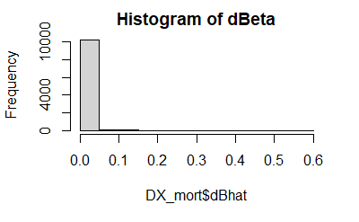

```r
hist(DX_mort$dBhat, main='Histogram of dBeta')
```

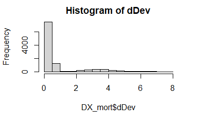

```r
hist(DX_mort$dDev, main='Histogram of dDev')
```

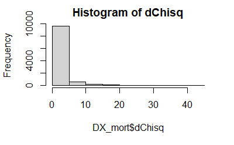

```r
hist(DX_mort$dChisq, main='Histogram of dChisq')
```

### 13.4.3 Residual plots

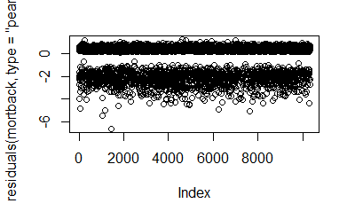

```r
plot(residuals(mortback, type='pearson'))
```

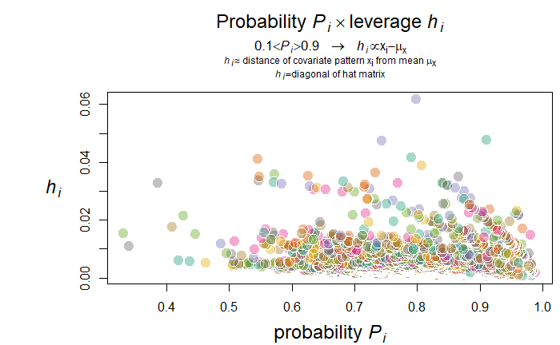

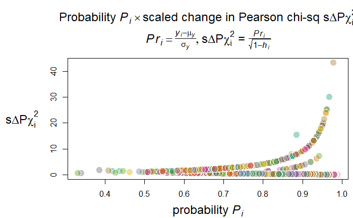

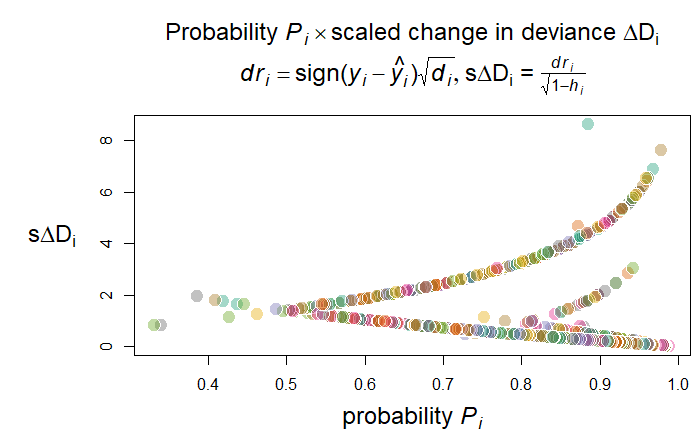

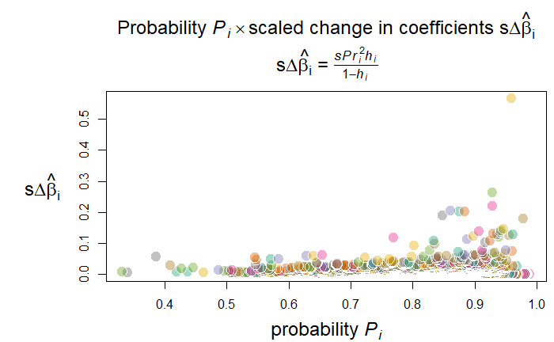

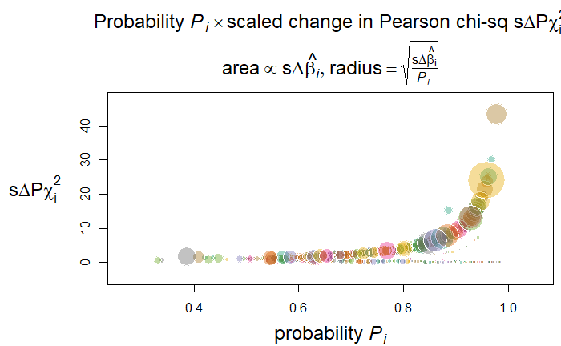

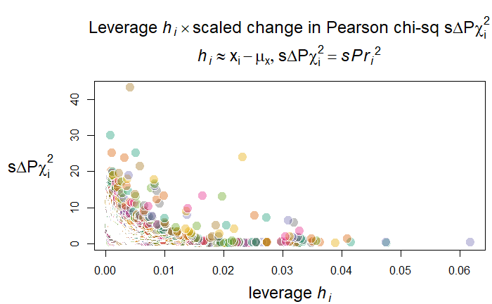

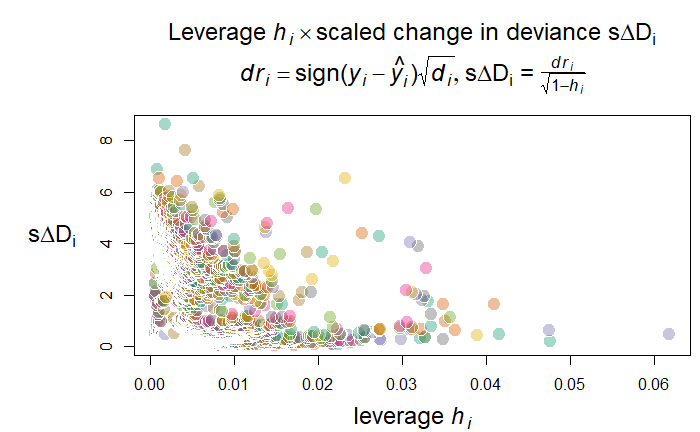

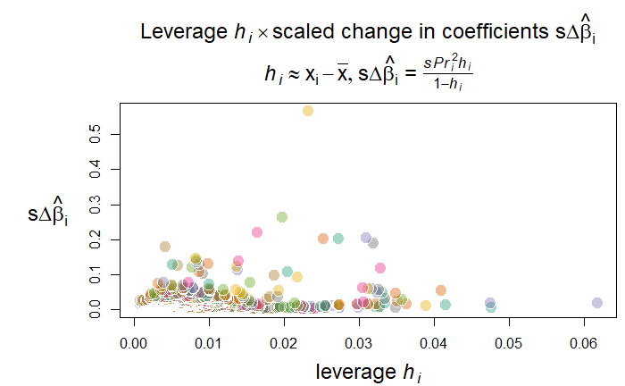

```r
plot(mortback, identify = TRUE, devNew = FALSE)
```

[figure not shown]

```r
NA
```

# 14 Coxph Model on Survival Rate

```r
library(survival)
library(hdnom)
```

## 14.1 Model Selection

```r
library(pec)
selectCox(Surv(DX_LASTCONTACT_DEATH_MONTHS,PUF_VITAL_STATUS==0) ~Chemo
             + AGE_cat
             + SEX
             + RACE2
             + SPANISH_ORIGIN2
             + CROWFLY
             + CDCC_TOTAL_BEST
             + TUMOR_SIZE_cat
             + GRADE
             + Neuroendocrine
             + Visceral_Pleural_Invasion
             + LYMPH_VASCULAR_INVASION2
             + Margins
             + Lymph_Nodes_Sampled
             + Excision_less_than1, data=NCDB_lung2, rule = "aic")
```

```
$fit
Cox Proportional Hazards Model

 rms::cph(formula = newform, data = data, surv = TRUE)

                        Model Tests    Discrimination
                                              Indexes
 Obs     10326    LR chi2    464.74    R2       0.047
 Events   1567    d.f.           25    Dxy      0.309
 Center 1.6595    Pr(> chi2) 0.0000    g        0.629
                  Score chi2 471.44    gr       1.875
                  Pr(> chi2) 0.0000

                                   Coef    S.E.   Wald Z Pr(>|Z|)
 Chemo=No Chemo                     0.3118 0.0782  3.99  <0.0001
 AGE_cat=60-70                      0.1579 0.0875  1.80  0.0713
 AGE_cat=70-80                      0.4275 0.0851  5.02  <0.0001
 AGE_cat=Above 80                   0.7133 0.1030  6.92  <0.0001
 AGE_cat=Below 50                  -0.2054 0.2418 -0.85  0.3955
 SEX=Male                           0.4527 0.0520  8.71  <0.0001
 SPANISH_ORIGIN2=Non-Hispanic       0.2694 0.1626  1.66  0.0976
 SPANISH_ORIGIN2=Unkown             0.5296 0.2390  2.22  0.0267
 CDCC_TOTAL_BEST                    0.1617 0.0246  6.57  <0.0001
 TUMOR_SIZE_cat=1cm-2cm             0.7850 0.3412  2.30  0.0214
 TUMOR_SIZE_cat=2cm-3cm             0.7407 0.3425  2.16  0.0306
 TUMOR_SIZE_cat=3cm-4cm             1.0182 0.3432  2.97  0.0030
 TUMOR_SIZE_cat=4cm-5cm             1.2191 0.3450  3.53  0.0004
 GRADE=Poorly differentiated        0.2342 0.0561  4.18  <0.0001
 GRADE=Undifferentiated             0.4700 0.1969  2.39  0.0170
 GRADE=Unknown                     -0.1344 0.0962 -1.40  0.1627
 GRADE=Well differentiated         -0.6216 0.1085 -5.73  <0.0001
 Visceral_Pleural_Invasion=Present  0.1711 0.0783  2.18  0.0289
 LYMPH_VASCULAR_INVASION2=Present   0.3019 0.0627  4.81  <0.0001
 LYMPH_VASCULAR_INVASION2=Unknown   0.0109 0.1110  0.10  0.9218
 Margins=Positive                  -0.1296 0.3256 -0.40  0.6905
 Margins=Zero                      -0.5315 0.2934 -1.81  0.0700
 Lymph_Nodes_Sampled=>=10          -0.1412 0.0533 -2.65  0.0081
 Lymph_Nodes_Sampled=Unknown       -0.1155 0.1275 -0.91  0.3648
 Excision_less_than1                0.3217 0.0725  4.44  <0.0001


$In
 [1] "Chemo"                     "AGE_cat"
 [3] "SEX"                       "SPANISH_ORIGIN2"
 [5] "CDCC_TOTAL_BEST"           "TUMOR_SIZE_cat"
 [7] "GRADE"                     "Visceral_Pleural_Invasion"
 [9] "LYMPH_VASCULAR_INVASION2"  "Margins"
[11] "Lymph_Nodes_Sampled"       "Excision_less_than1"

$call
selectCox(formula = Surv(DX_LASTCONTACT_DEATH_MONTHS, PUF_VITAL_STATUS ==
    0) ~ Chemo + AGE_cat + SEX + RACE2 + SPANISH_ORIGIN2 + CROWFLY +
    CDCC_TOTAL_BEST + TUMOR_SIZE_cat + GRADE + Neuroendocrine +
    Visceral_Pleural_Invasion + LYMPH_VASCULAR_INVASION2 + Margins +
    Lymph_Nodes_Sampled + Excision_less_than1, data = NCDB_lung2,
    rule = "aic")

attr(,"class")
[1] "selectCox"
```

# 15 Backward selection model

```r
library(labelled)
var_label(NCDB_lung2) = list(AGE_cat = 'Age',
               SEX = 'Gender',
               CDCC_TOTAL_BEST = 'Charlson-Deyo Score',
               TUMOR_SIZE_cat = 'Tumor Size',
               GRADE='Grade',
               Margins='Margins',
               LYMPH_VASCULAR_INVASION2 = 'Vascular Invasion',
               Visceral_Pleural_Invasion ='Visceral Pleural Invasion',
               Lymph_Nodes_Sampled = 'Lymph nodes sampled',
               Excision_less_than1='Excision/Resection of <1 lobe ')




NCDB_lung2$Chemo=relevel(as.factor(NCDB_lung2$Chemo), ref="No Chemo" )
cox_fit <- coxph(Surv(DX_LASTCONTACT_DEATH_MONTHS,PUF_VITAL_STATUS==0) ~Chemo+
                      AGE_cat+
                      SEX +
                      CDCC_TOTAL_BEST  +
                      TUMOR_SIZE_cat  +
                      GRADE  +
                      Visceral_Pleural_Invasion+
                      LYMPH_VASCULAR_INVASION2+
                      Margins  +
                      Lymph_Nodes_Sampled +
                      Excision_less_than1,
                    data = NCDB_lung2)
summary(cox_fit)
```

```
Call:
coxph(formula = Surv(DX_LASTCONTACT_DEATH_MONTHS, PUF_VITAL_STATUS ==
    0) ~ Chemo + AGE_cat + SEX + CDCC_TOTAL_BEST + TUMOR_SIZE_cat +
    GRADE + Visceral_Pleural_Invasion + LYMPH_VASCULAR_INVASION2 +
    Margins + Lymph_Nodes_Sampled + Excision_less_than1, data = NCDB_lung2)

  n= 10326, number of events= 1567

                                      coef exp(coef)  se(coef)      z Pr(>|z|)
ChemoChemo                       -0.311232  0.732544  0.078121 -3.984 6.78e-05 ***
AGE_cat60-70                      0.156310  1.169188  0.087533  1.786  0.07414 .
AGE_cat70-80                      0.425802  1.530817  0.085145  5.001 5.71e-07 ***
AGE_catAbove 80                   0.715631  2.045476  0.103033  6.946 3.77e-12 ***
AGE_catBelow 50                  -0.206658  0.813298  0.241744 -0.855  0.39263
SEXMale                           0.449974  1.568271  0.051996  8.654  < 2e-16 ***
CDCC_TOTAL_BEST                   0.162301  1.176214  0.024594  6.599 4.13e-11 ***
TUMOR_SIZE_cat1cm-2cm             0.788410  2.199895  0.341354  2.310  0.02091 *
TUMOR_SIZE_cat2cm-3cm             0.743616  2.103528  0.342654  2.170  0.02999 *
TUMOR_SIZE_cat3cm-4cm             1.015815  2.761614  0.343348  2.959  0.00309 **
TUMOR_SIZE_cat4cm-5cm             1.217129  3.377477  0.345078  3.527  0.00042 ***
GRADEPoorly differentiated        0.231204  1.260116  0.056062  4.124 3.72e-05 ***
GRADEUndifferentiated             0.466895  1.595034  0.196952  2.371  0.01776 *
GRADEUnknown                     -0.139481  0.869809  0.096189 -1.450  0.14704
GRADEWell differentiated         -0.624524  0.535516  0.108447 -5.759 8.47e-09 ***
Visceral_Pleural_InvasionPresent  0.165435  1.179906  0.078303  2.113  0.03462 *
LYMPH_VASCULAR_INVASION2Present   0.300926  1.351109  0.062741  4.796 1.62e-06 ***
LYMPH_VASCULAR_INVASION2Unknown   0.009128  1.009169  0.111038  0.082  0.93449
MarginsPositive                  -0.128158  0.879714  0.325515 -0.394  0.69380
MarginsZero                      -0.532042  0.587404  0.293306 -1.814  0.06969 .
Lymph_Nodes_Sampled>=10          -0.137492  0.871542  0.053321 -2.579  0.00992 **
Lymph_Nodes_SampledUnknown       -0.113411  0.892784  0.127486 -0.890  0.37368
Excision_less_than1TRUE           0.320638  1.378007  0.072466  4.425 9.66e-06 ***
---
Signif. codes:  0 ‘***’ 0.001 ‘**’ 0.01 ‘*’ 0.05 ‘.’ 0.1 ‘ ’ 1

                                 exp(coef) exp(-coef) lower .95 upper .95
ChemoChemo                          0.7325     1.3651    0.6285    0.8537
AGE_cat60-70                        1.1692     0.8553    0.9849    1.3880
AGE_cat70-80                        1.5308     0.6532    1.2955    1.8088
AGE_catAbove 80                     2.0455     0.4889    1.6714    2.5032
```

[output cut: 9 more lines]

```
GRADEUnknown                        0.8698     1.1497    0.7204    1.0503
GRADEWell differentiated            0.5355     1.8674    0.4330    0.6623
Visceral_Pleural_InvasionPresent    1.1799     0.8475    1.0120    1.3756
LYMPH_VASCULAR_INVASION2Present     1.3511     0.7401    1.1948    1.5279
LYMPH_VASCULAR_INVASION2Unknown     1.0092     0.9909    0.8118    1.2545
MarginsPositive                     0.8797     1.1367    0.4648    1.6650
MarginsZero                         0.5874     1.7024    0.3306    1.0438
Lymph_Nodes_Sampled>=10             0.8715     1.1474    0.7851    0.9676
Lymph_Nodes_SampledUnknown          0.8928     1.1201    0.6954    1.1462
Excision_less_than1TRUE             1.3780     0.7257    1.1956    1.5883

Concordance= 0.654  (se = 0.007 )
Likelihood ratio test= 459.7  on 23 df,   p=<2e-16
Wald test            = 452.9  on 23 df,   p=<2e-16
Score (logrank) test = 466.9  on 23 df,   p=<2e-16
```

## 15.1 Table 2 Adjust

```r
include_columns3 = c('DX_LASTCONTACT_DEATH_MONTHS',
                     'PUF_VITAL_STATUS',
                     'Chemo' ,
                     'AGE',
                     'AGE_cat' ,
                     'SEX' ,
                     'CDCC_TOTAL_BEST',
                     'TUMOR_SIZE_cat',
                     'GRADE',
                     'Pathology',
                     'Visceral_Pleural_Invasion',
                     'LYMPH_VASCULAR_INVASION2',
                     'Margins',
                     'Lymph_Nodes_Sampled',
                     'Excision_less_than1')

relabel_columns3=list(AGE_cat ~ 'Age',
                     SEX ~ 'Gender',
                     CDCC_TOTAL_BEST ~ 'Charlson-Deyo Score',
                     TUMOR_SIZE_cat ~ 'Tumor Size',
                     GRADE~'Grade',
                     LYMPH_VASCULAR_INVASION2 ~ 'Vascular Invasion',
                     Visceral_Pleural_Invasion~'Visceral Pleural Invasion',
                     Lymph_Nodes_Sampled ~ 'Lymph nodes sampled',
                     Excision_less_than1='Excision/Resection of <1 lobe ')

tbl_uvsurv <-
  NCDB_lung[, include_columns3] %>%
  tbl_uvregression(
    method = coxph,
    y = Surv(DX_LASTCONTACT_DEATH_MONTHS,PUF_VITAL_STATUS==1),
    exponentiate = TRUE,
    label=relabel_columns3
  )%>%
  modify_header(
    update = list(
      estimate ~ "**HR**"
    )) %>%  modify_footnote(
    update = estimate ~
      "HR=Hazard Ratio"
  )

tbl_surv <- cox_fit %>% tbl_regression(exponentiate = TRUE,label=relabel_columns3
                                       )%>%
  modify_header(
    update = list(
      estimate ~ "**HR**"
    )) %>%  modify_footnote(
    update = estimate ~
      "HR=Hazard Ratio"
  )

table2_merge <- tbl_merge(
  list(tbl_uvsurv, tbl_surv),
  tab_spanner = c("**Univariate analysis**", "**Multivariable analysis**"))

table2_merge%>%as_flex_table()%>%flextable::save_as_docx(., path = "table2_merge.docx")
table2_merge
```

[output not shown]

<sup>1</sup> HR=Hazard Ratio  
<sup>2</sup> HR = Hazard Ratio, CI = Confidence Interval